# LBSPR method: Assessing the sensitivity of length-indicator methods for resources in the Atlantic waters

2021-01-18

# 1 Nephrops norvegicus FU25

## 1.1 Nephrops norvegicus FU25 Males

Life history parameters:

$L_{inf}^{LIT}$ = 86 mm ${M/k}^{LIT}$ = 1.9 $L_{50}$= 25 mm $L_{95}$= 28.75 mm

Reference model:

```r
Hke1Pars <- new("LB_pars")
Hke1Pars@Linf <- 86
Hke1Pars@L50 <- 25
Hke1Pars@L95 <- 28.75
Hke1Pars@MK <- 1.9
Hke1Pars@M <- 0.095
Hke1Pars@L_units <- "mm"
```

```r
HkeLenFreq1 <- new("LB_lengths", LB_pars=Hke1Pars, file="FU25_Males.csv", dataType="freq", header=TRUE)
HkeLenFreq1@L_units <- Hke1Pars@L_units

A=HkeLenFreq1@LData
B=is.na(HkeLenFreq1@LData)

for (i in 1:68){
  for (j in 1:38){
    if(B[i,j]==TRUE){
    A[i,j]=0}
  }

}

HkeLenFreq1@LData=A

HkeLenFreq1
```

```
## An object of class "LB_lengths"
## Slot "LMids":
##  [1] 19.5 20.5 21.5 22.5 23.5 24.5 25.5 26.5 27.5 28.5 29.5 30.5 31.5 32.5 33.5
## [16] 34.5 35.5 36.5 37.5 38.5 39.5 40.5 41.5 42.5 43.5 44.5 45.5 46.5 47.5 48.5
## [31] 49.5 50.5 51.5 52.5 53.5 54.5 55.5 56.5 57.5 58.5 59.5 60.5 61.5 62.5 63.5
## [46] 64.5 65.5 66.5 67.5 68.5 69.5 70.5 71.5 72.5 73.5 74.5 75.5 76.5 77.5 78.5
## [61] 79.5 80.5 81.5 82.5 83.5 84.5 85.5 86.5
##
## Slot "LData":
##    1982.00 1983.00 1984.00 1985.00 1986.00 1987.00 1988.00 1989.00 1990.00
## 1     8148    5570    4949       0       0       0       0       0       0
## 2     1059    4154   15621       0   34637     438     301       0       0
## 3     3886     273       0       0    1064   49328     822       0       0
## 4     4968   27978       0   14601     440       0   29690     715     628
## 5    17598   38825    9482   32234   26483    6506    3623    1624   11625
```

[output cut: 353 more lines]

```r
Fit1 <- LBSPRfit(Hke1Pars, HkeLenFreq1, verbose = FALSE)
```

Underestimated ${M/k}^{LIT}$.

```r
Hke1ParsMK <-Hke1Pars
Hke1ParsMK@MK <- 0.75*1.90


HkeLenFreq1MK <- new("LB_lengths", LB_pars=Hke1ParsMK, file="FU25_Males.csv", dataType="freq", header=TRUE)
HkeLenFreq1MK@L_units <- Hke1ParsMK@L_units


A=HkeLenFreq1MK@LData
B=is.na(HkeLenFreq1MK@LData)

for (i in 1:68){
  for (j in 1:38){
    if(B[i,j]==TRUE){
    A[i,j]=0}
  }

}

HkeLenFreq1MK@LData=A

Fit1MK <- LBSPRfit(Hke1ParsMK, HkeLenFreq1MK, verbose = FALSE)
```

Overestimated ${M/k}^{LIT}$.

```r
Hke2ParsMK <-Hke1Pars
Hke2ParsMK@MK <- 1.25*1.90


HkeLenFreq2MK <- new("LB_lengths", LB_pars=Hke2ParsMK, file="FU25_Males.csv", dataType="freq", header=TRUE)
HkeLenFreq2MK@L_units <- Hke2ParsMK@L_units

A=HkeLenFreq2MK@LData
B=is.na(HkeLenFreq2MK@LData)

for (i in 1:68){
  for (j in 1:38){
    if(B[i,j]==TRUE){
    A[i,j]=0}
  }

}

HkeLenFreq2MK@LData=A


Fit2MK <- LBSPRfit(Hke2ParsMK, HkeLenFreq2MK, verbose = FALSE)
```

M/k=1.5.

```r
Hke3ParsMK <-Hke1Pars
Hke3ParsMK@MK <- 1.5

HkeLenFreq3MK <- new("LB_lengths", LB_pars=Hke3ParsMK, file="FU25_Males.csv", dataType="freq", header=TRUE)
HkeLenFreq3MK@L_units <- Hke3ParsMK@L_units


A=HkeLenFreq3MK@LData
B=is.na(HkeLenFreq3MK@LData)

for (i in 1:68){
  for (j in 1:38){
    if(B[i,j]==TRUE){
    A[i,j]=0}
  }

}

HkeLenFreq3MK@LData=A


Fit3MK <- LBSPRfit(Hke3ParsMK, HkeLenFreq3MK, verbose = FALSE)
```

Underestimated $L_{inf}^{LIT}$.

```r
Hke1ParsLinf <-Hke1Pars
Hke1ParsLinf@Linf <- 0.75*86

HkeLenFreq1Linf <- new("LB_lengths", LB_pars=Hke1ParsLinf, file="FU25_Males.csv", dataType="freq", header=TRUE)
HkeLenFreq1Linf@L_units <- Hke1ParsLinf@L_units

A=HkeLenFreq1Linf@LData
B=is.na(HkeLenFreq1Linf@LData)

for (i in 1:68){
  for (j in 1:38){
    if(B[i,j]==TRUE){
    A[i,j]=0}
  }

}

HkeLenFreq1Linf@LData=A


Fit1Linf <- LBSPRfit(Hke1ParsLinf, HkeLenFreq1Linf, verbose = FALSE)
```

Overestimated $L_{inf}^{LIT}$.

```r
Hke2ParsLinf <-Hke1Pars
Hke2ParsLinf@Linf <- 1.25*86

HkeLenFreq2Linf <- new("LB_lengths", LB_pars=Hke2ParsLinf, file="FU25_Males.csv", dataType="freq", header=TRUE)
HkeLenFreq2Linf@L_units <- Hke2ParsLinf@L_units

A=HkeLenFreq2Linf@LData
B=is.na(HkeLenFreq2Linf@LData)

for (i in 1:68){
  for (j in 1:38){
    if(B[i,j]==TRUE){
    A[i,j]=0}
  }

}

HkeLenFreq2Linf@LData=A


HkeLenFreq2Linf@LMids=seq(19.5,107.5,by=1)
A=HkeLenFreq2Linf@LData
for (i in 1:21){
A=rbind(A,HkeLenFreq2Linf@LData[68,])}

A[69:89,1:38]=rep(0,38)


HkeLenFreq2Linf@LData=A
Hke2ParsLinf <-Hke1Pars
Hke2ParsLinf@Linf <- 1.25*86
Fit2Linf <- LBSPRfit(Hke2ParsLinf, HkeLenFreq2Linf, verbose = FALSE)
```

Plots:

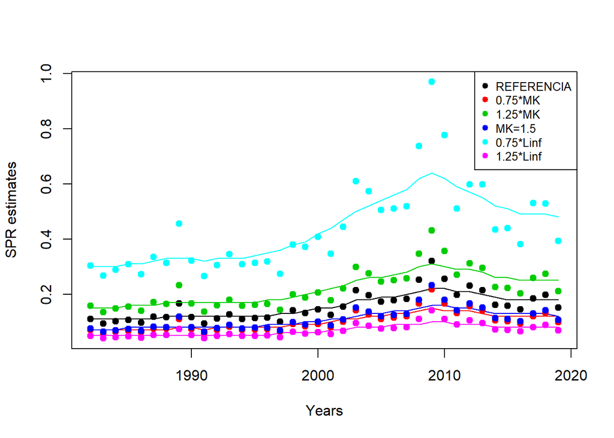

```r
smoothEsts1 <- data.frame(Fit1@Ests)
smoothEsts1MK <- data.frame(Fit1MK@Ests)
smoothEsts2MK <- data.frame(Fit2MK@Ests)
smoothEsts3MK <- data.frame(Fit3MK@Ests)
smoothEsts1Linf <- data.frame(Fit1Linf@Ests)
smoothEsts2Linf <- data.frame(Fit2Linf@Ests)


spr1=Fit1@SPR
sprmk1=Fit1MK@SPR
sprmk2=Fit2MK@SPR
sprmk3=Fit3MK@SPR
sprL1=Fit1Linf@SPR
sprL2=Fit2Linf@SPR

min=min(c(spr1,sprmk1,sprmk2,sprmk3,sprL1,sprL2))
max=max(c(spr1,sprmk1,sprmk2,sprmk3,sprL1,sprL2))

plot(1982:2019,spr1,ylim=c(min,max),xlab="Years",ylab="SPR estimates",pch=19)

lines(1982:2019, smoothEsts1$SPR, lwd = 1,col="black")
lines(1982:2019, smoothEsts1MK$SPR, lwd = 1,col=2)
lines(1982:2019, smoothEsts2MK$SPR, lwd = 1,col=3)
lines(1982:2019, smoothEsts3MK$SPR, lwd = 1,col=4)
lines(1982:2019, smoothEsts1Linf$SPR, lwd = 1,col=5)
lines(1982:2019, smoothEsts2Linf$SPR, lwd = 1,col=6)


points(1982:2019, sprmk1,col=2,pch=19)
points(1982:2019, sprmk2,col=3,pch=19)
points(1982:2019, sprmk3,col=4,pch=19)
points(1982:2019, sprL1,col=5,pch=19)
points(1982:2019, sprL2,col=6,pch=19)

legend("topright", legend=c("REFERENCIA", "0.75*MK","1.25*MK","MK=1.5","0.75*Linf","1.25*Linf"),
       col=c("black", 2:6), pch=19, cex=0.8)
```

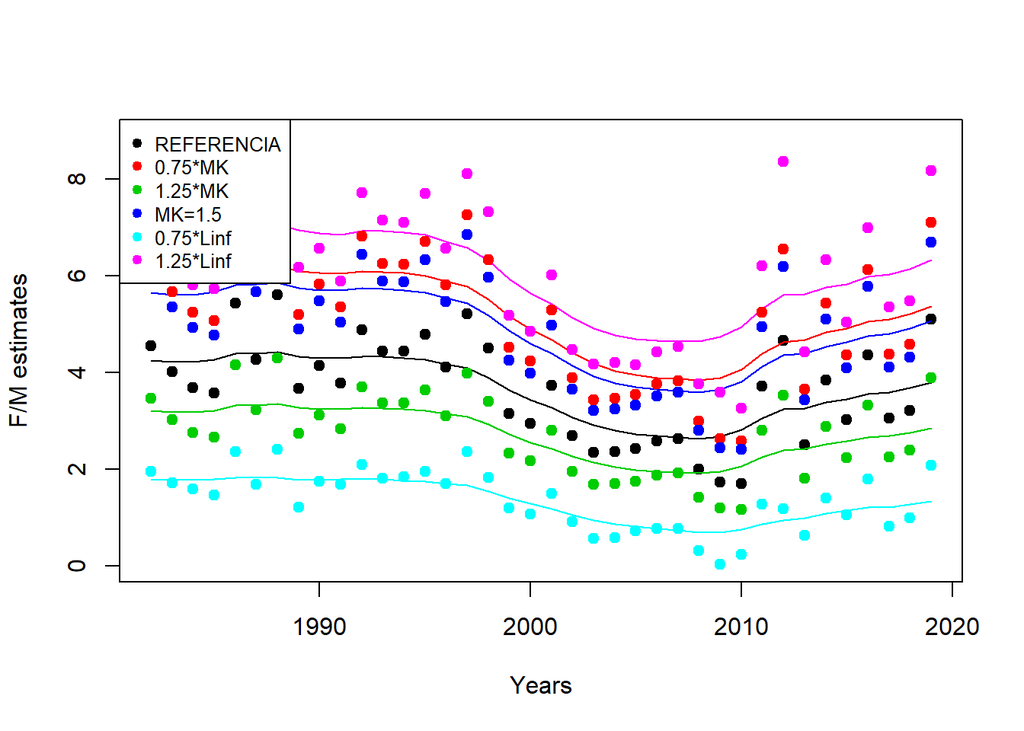

```r
fm1=Fit1@FM
fmmk1=Fit1MK@FM
fmmk2=Fit2MK@FM
fmmk3=Fit3MK@FM
fmL1=Fit1Linf@FM
fmL2=Fit2Linf@FM

min=min(c(fm1,fmmk1,fmmk2,fmmk3,fmL1,fmL2))
max=max(c(fm1,fmmk1,fmmk2,fmmk3,fmL1,fmL2))

plot(1982:2019,fm1,ylim=c(min,max),xlab="Years",ylab="F/M estimates",pch=19)

lines(1982:2019, smoothEsts1$FM, lwd = 1,col="black")
lines(1982:2019, smoothEsts1MK$FM, lwd = 1,col=2)
lines(1982:2019, smoothEsts2MK$FM, lwd = 1,col=3)
lines(1982:2019, smoothEsts3MK$FM, lwd = 1,col=4)
lines(1982:2019, smoothEsts1Linf$FM, lwd = 1,col=5)
lines(1982:2019, smoothEsts2Linf$FM, lwd = 1,col=6)


points(1982:2019, fmmk1,col=2,pch=19)
points(1982:2019, fmmk2,col=3,pch=19)
points(1982:2019, fmmk3,col=4,pch=19)
points(1982:2019, fmL1,col=5,pch=19)
points(1982:2019, fmL2,col=6,pch=19)

legend("topleft", legend=c("REFERENCIA", "0.75*MK","1.25*MK","MK=1.5","0.75*Linf","1.25*Linf"),
       col=c("black", 2:6), pch=19, cex=0.8)
```

## 1.2 Nephrops norvegicus FU25 Females

Life history parameters:

$L_{inf}^{LIT}$ = 71 mm ${M/k}^{LIT}$ = 1.9 $L_{50}$=28 mm $L_{95}$=32.2 mm

```r
Hke1Pars <- new("LB_pars")
Hke1Pars@Linf <- 71
Hke1Pars@L50 <- 28
Hke1Pars@L95 <- 32.2
Hke1Pars@MK <- 1.9
Hke1Pars@L_units <- "mm"
```

Reference model:

```r
HkeLenFreq1 <- new("LB_lengths", LB_pars=Hke1Pars, file="FU25_Females.csv", dataType="freq", header=TRUE)
HkeLenFreq1@L_units <- Hke1Pars@L_units
```

```r
HkeLenFreq1
```

```
## An object of class "LB_lengths"
## Slot "LMids":
##  [1] 15.5 16.5 17.5 18.5 19.5 20.5 21.5 22.5 23.5 24.5 25.5 26.5 27.5 28.5 29.5
## [16] 30.5 31.5 32.5 33.5 34.5 35.5 36.5 37.5 38.5 39.5 40.5 41.5 42.5 43.5 44.5
## [31] 45.5 46.5 47.5 48.5 49.5 50.5 51.5 52.5 53.5 54.5 55.5 56.5 57.5 58.5 59.5
## [46] 60.5 61.5 62.5 63.5 64.5 65.5 66.5 67.5 68.5 69.5 70.5 71.5
##
## Slot "LData":
##      1982   1983   1984   1985   1986   1987   1988   1989   1990   1991   1992
## 1       0      0      0      0      0      0      0      0      0      0      0
## 2       0      0      0      0      0      0      0      0      0      0      0
## 3       0      0      0      0      0      0      0      0      0      0      0
## 4       0      0      0      0      0      0      0      0      0      0      0
## 5     791      0      0      0      0      0      0      0      0      0      0
## 6       0  13378      0      0    782      0      0      0   2494      0      0
```

[output cut: 239 more lines]

```r
Fit1 <- LBSPRfit(Hke1Pars, HkeLenFreq1, verbose = FALSE)
```

Underestimated ${M/k}^{LIT}$.

```r
Hke1ParsMK <-Hke1Pars
Hke1ParsMK@MK <- 0.75*1.90


HkeLenFreq1MK <- new("LB_lengths", LB_pars=Hke1ParsMK, file="FU25_Females.csv", dataType="freq", header=TRUE)
HkeLenFreq1MK@L_units <- Hke1ParsMK@L_units


Fit1MK <- LBSPRfit(Hke1ParsMK, HkeLenFreq1MK, verbose = FALSE)
```

Overestimated ${M/k}^{LIT}$.

```r
Hke2ParsMK <-Hke1Pars
Hke2ParsMK@MK <- 1.25*1.90


HkeLenFreq2MK <- new("LB_lengths", LB_pars=Hke2ParsMK, file="FU25_Females.csv", dataType="freq", header=TRUE)
HkeLenFreq2MK@L_units <- Hke2ParsMK@L_units


Fit2MK <- LBSPRfit(Hke2ParsMK, HkeLenFreq2MK, verbose = FALSE)
```

M/k=1.5.

```r
Hke3ParsMK <-Hke1Pars
Hke3ParsMK@MK <- 1.5

HkeLenFreq3MK <- new("LB_lengths", LB_pars=Hke3ParsMK, file="FU25_Females.csv", dataType="freq", header=TRUE)
HkeLenFreq3MK@L_units <- Hke3ParsMK@L_units

Fit3MK <- LBSPRfit(Hke3ParsMK, HkeLenFreq3MK, verbose = FALSE)
```

Underestimated $L_{inf}^{LIT}$.

```r
Hke1ParsLinf <-Hke1Pars
Hke1ParsLinf@Linf <- 0.75*71

HkeLenFreq1Linf <- new("LB_lengths", LB_pars=Hke1ParsLinf, file="FU25_Females.csv", dataType="freq", header=TRUE)
HkeLenFreq1Linf@L_units <- Hke1ParsLinf@L_units


Fit1Linf <- LBSPRfit(Hke1ParsLinf, HkeLenFreq1Linf, verbose = FALSE)
```

Overestimated $L_{inf}^{LIT}$.

```r
Hke2ParsLinf <-Hke1Pars
Hke2ParsLinf@Linf <- 1.25*71

HkeLenFreq2Linf <- new("LB_lengths", LB_pars=Hke2ParsLinf, file="FU25_Females.csv", dataType="freq", header=TRUE)
HkeLenFreq2Linf@L_units <- Hke2ParsLinf@L_units


HkeLenFreq2Linf@LMids=seq(15.5,89.5,by=1)
A=HkeLenFreq2Linf@LData
for (i in 1:18){
A=rbind(A,HkeLenFreq2Linf@LData[57,])}

A[58:75,1:38]=rep(0,38)


HkeLenFreq2Linf@LData=A
Hke2ParsLinf <-Hke1Pars
Hke2ParsLinf@Linf <- 1.25*71
Fit2Linf <- LBSPRfit(Hke2ParsLinf, HkeLenFreq2Linf, verbose = FALSE)
```

Plots:

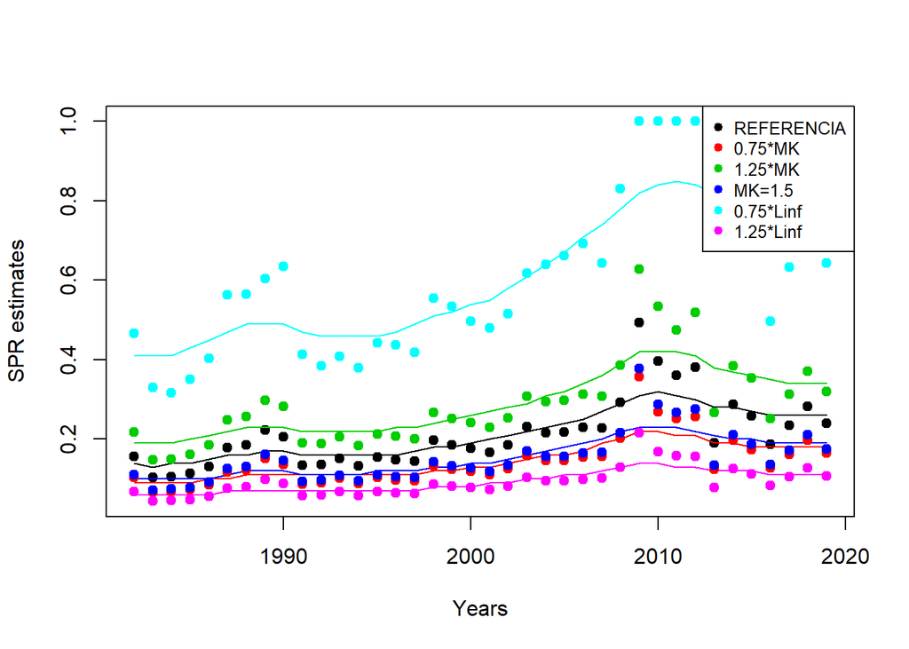

```r
smoothEsts1 <- data.frame(Fit1@Ests)
smoothEsts1MK <- data.frame(Fit1MK@Ests)
smoothEsts2MK <- data.frame(Fit2MK@Ests)
smoothEsts3MK <- data.frame(Fit3MK@Ests)
smoothEsts1Linf <- data.frame(Fit1Linf@Ests)
smoothEsts2Linf <- data.frame(Fit2Linf@Ests)


spr1=Fit1@SPR
sprmk1=Fit1MK@SPR
sprmk2=Fit2MK@SPR
sprmk3=Fit3MK@SPR
sprL1=Fit1Linf@SPR
sprL2=Fit2Linf@SPR

min=min(c(spr1,sprmk1,sprmk2,sprmk3,sprL1,sprL2))
max=max(c(spr1,sprmk1,sprmk2,sprmk3,sprL1,sprL2))

plot(1982:2019,spr1,ylim=c(min,max),xlab="Years",ylab="SPR estimates",pch=19)

lines(1982:2019, smoothEsts1$SPR, lwd = 1,col="black")
lines(1982:2019, smoothEsts1MK$SPR, lwd = 1,col=2)
lines(1982:2019, smoothEsts2MK$SPR, lwd = 1,col=3)
lines(1982:2019, smoothEsts3MK$SPR, lwd = 1,col=4)
lines(1982:2019, smoothEsts1Linf$SPR, lwd = 1,col=5)
lines(1982:2019, smoothEsts2Linf$SPR, lwd = 1,col=6)


points(1982:2019, sprmk1,col=2,pch=19)
points(1982:2019, sprmk2,col=3,pch=19)
points(1982:2019, sprmk3,col=4,pch=19)
points(1982:2019, sprL1,col=5,pch=19)
points(1982:2019, sprL2,col=6,pch=19)

legend("topright", legend=c("REFERENCIA", "0.75*MK","1.25*MK","MK=1.5","0.75*Linf","1.25*Linf"),
       col=c("black", 2:6), pch=19, cex=0.8)
```

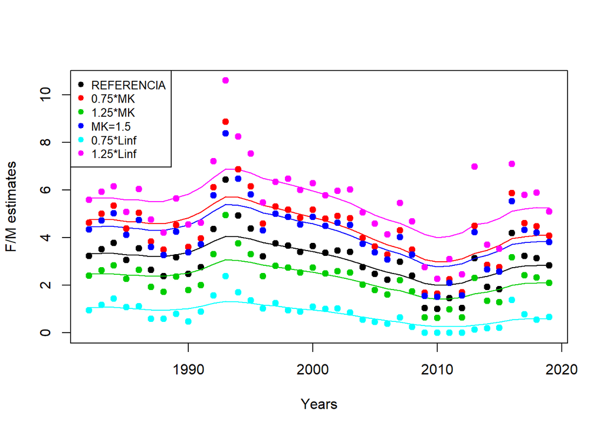

```r
fm1=Fit1@FM
fmmk1=Fit1MK@FM
fmmk2=Fit2MK@FM
fmmk3=Fit3MK@FM
fmL1=Fit1Linf@FM
fmL2=Fit2Linf@FM

min=min(c(fm1,fmmk1,fmmk2,fmmk3,fmL1,fmL2))
max=max(c(fm1,fmmk1,fmmk2,fmmk3,fmL1,fmL2))

plot(1982:2019,fm1,ylim=c(min,max),xlab="Years",ylab="F/M estimates",pch=19)

lines(1982:2019, smoothEsts1$FM, lwd = 1,col="black")
lines(1982:2019, smoothEsts1MK$FM, lwd = 1,col=2)
lines(1982:2019, smoothEsts2MK$FM, lwd = 1,col=3)
lines(1982:2019, smoothEsts3MK$FM, lwd = 1,col=4)
lines(1982:2019, smoothEsts1Linf$FM, lwd = 1,col=5)
lines(1982:2019, smoothEsts2Linf$FM, lwd = 1,col=6)


points(1982:2019, fmmk1,col=2,pch=19)
points(1982:2019, fmmk2,col=3,pch=19)
points(1982:2019, fmmk3,col=4,pch=19)
points(1982:2019, fmL1,col=5,pch=19)
points(1982:2019, fmL2,col=6,pch=19)

legend("topleft", legend=c("REFERENCIA", "0.75*MK","1.25*MK","MK=1.5","0.75*Linf","1.25*Linf"),
       col=c("black", 2:6), pch=19, cex=0.8)
```

# 2 Nephrops norvegicus FU2627

## 2.1 Nephrops norvegicus FU2627 Males

Life history parameters:

$L_{inf}^{LIT}$ = 80 mm ${M/k}^{LIT}$ =2 $L_{50}$=28 mm $L_{95}$=32.2 mm

```r
Nepmales1Pars <- new("LB_pars")
Nepmales1Pars@Linf <- 80
Nepmales1Pars@L50 <- 28
Nepmales1Pars@L95 <- 32.2
Nepmales1Pars@MK <- 2
Nepmales1Pars@L_units <- "mm"
```

Reference model:

```r
NepmalesLenFreq1 <- new("LB_lengths", LB_pars=Nepmales1Pars, file="FU2627_tallasMales_1988_2019_2.csv", dataType="freq", header=TRUE)
NepmalesLenFreq1@L_units <- Nepmales1Pars@L_units
```

```r
NepmalesLenFreq1
```

```
## An object of class "LB_lengths"
## Slot "LMids":
##  [1]  12.5  13.5  14.5  15.5  16.5  17.5  18.5  19.5  20.5  21.5  22.5  23.5
## [13]  24.5  25.5  26.5  27.5  28.5  29.5  30.5  31.5  32.5  33.5  34.5  35.5
## [25]  36.5  37.5  38.5  39.5  40.5  41.5  42.5  43.5  44.5  45.5  46.5  47.5
## [37]  48.5  49.5  50.5  51.5  52.5  53.5  54.5  55.5  56.5  57.5  58.5  59.5
## [49]  60.5  61.5  62.5  63.5  64.5  65.5  66.5  67.5  68.5  69.5  70.5  71.5
## [61]  72.5  73.5  74.5  75.5  76.5  77.5  78.5  79.5  80.5  81.5  82.5  83.5
## [73]  84.5  85.5  86.5  87.5  88.5  89.5  90.5  91.5  92.5  93.5  94.5  95.5
## [85]  96.5  97.5  98.5  99.5 100.5
##
## Slot "LData":
##       1988    1989    1990    1991   1992   1993   1994   1995   1996   1997
## 1        0       0    7594       0      0      0      0      0      0      0
## 2        0   66181    8178       0      0      0      0      0      0      0
```

[output cut: 281 more lines]

```r
Fit1 <- LBSPRfit(Nepmales1Pars, NepmalesLenFreq1, verbose = FALSE)
```

Underestimated ${M/k}^{LIT}$.

```r
Nepmales1ParsMK <-Nepmales1Pars
Nepmales1ParsMK@MK <- 0.75*2


NepmalesLenFreq1MK <- new("LB_lengths", LB_pars=Nepmales1ParsMK, file="FU2627_tallasMales_1988_2019_2.csv", dataType="freq", header=TRUE)
NepmalesLenFreq1MK@L_units <- Nepmales1ParsMK@L_units


Fit1MK <- LBSPRfit(Nepmales1ParsMK, NepmalesLenFreq1MK,verbose=FALSE)
```

Overestimated ${M/k}^{LIT}$.

```r
Nepmales2ParsMK <-Nepmales1Pars
Nepmales2ParsMK@MK <- 1.25*2


NepmalesLenFreq2MK <- new("LB_lengths", LB_pars=Nepmales2ParsMK, file="FU2627_tallasMales_1988_2019_2.csv", dataType="freq", header=TRUE)
NepmalesLenFreq2MK@L_units <- Nepmales2ParsMK@L_units


Fit2MK <- LBSPRfit(Nepmales2ParsMK, NepmalesLenFreq2MK,verbose = FALSE)
```

Underestimated $L_{inf}^{LIT}$.

```r
Nepmales1ParsLinf <-Nepmales1Pars
Nepmales1ParsLinf@Linf <- 0.75*80

NepmalesLenFreq1Linf <- new("LB_lengths", LB_pars=Nepmales1ParsLinf, file="FU2627_tallasMales_1988_2019_2.csv", dataType="freq", header=TRUE)
NepmalesLenFreq1Linf@L_units <- Nepmales1ParsLinf@L_units


Fit1Linf <- LBSPRfit(Nepmales1ParsLinf, NepmalesLenFreq1Linf,verbose = FALSE)
```

Overestimated $L_{inf}^{LIT}$.

```r
Nepmales2ParsLinf <-Nepmales1Pars
Nepmales2ParsLinf@Linf <- 1.25*80

NepmalesLenFreq2Linf <- new("LB_lengths", LB_pars=Nepmales2ParsLinf, file="FU2627_tallasMales_1988_2019_2.csv", dataType="freq", header=TRUE)
NepmalesLenFreq2Linf@L_units <- Nepmales2ParsLinf@L_units


Fit2Linf <- LBSPRfit(Nepmales2ParsLinf, NepmalesLenFreq2Linf, verbose = FALSE)
```

Plots:

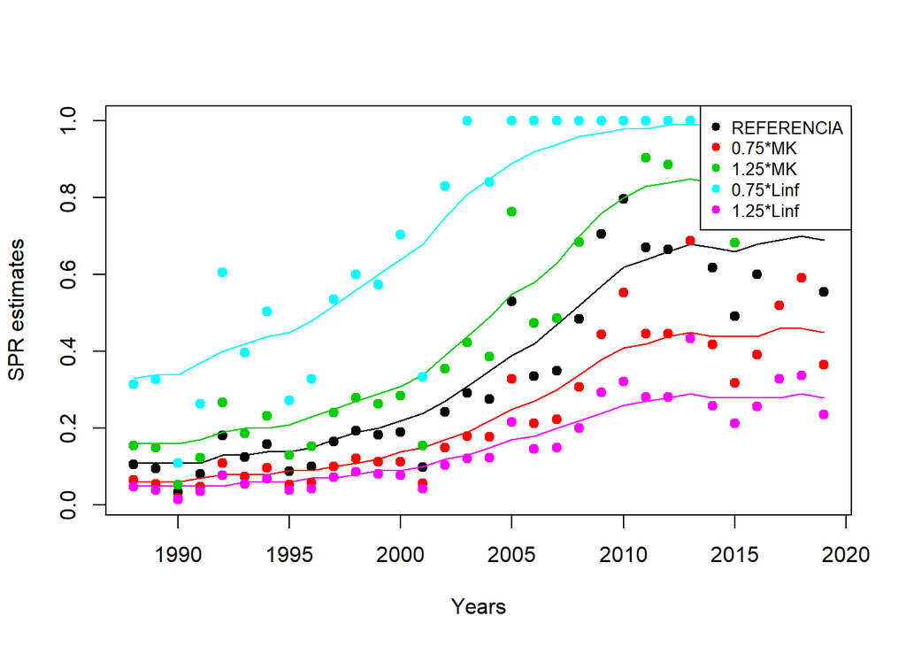

```r
smoothEsts1 <- data.frame(Fit1@Ests)
smoothEsts1MK <- data.frame(Fit1MK@Ests)
smoothEsts2MK <- data.frame(Fit2MK@Ests)
smoothEsts1Linf <- data.frame(Fit1Linf@Ests)
smoothEsts2Linf <- data.frame(Fit2Linf@Ests)


spr1=Fit1@SPR
sprmk1=Fit1MK@SPR
sprmk2=Fit2MK@SPR
sprL1=Fit1Linf@SPR
sprL2=Fit2Linf@SPR


min=min(c(spr1,sprmk1,sprmk2,sprL1,sprL2))
max=max(c(spr1,sprmk1,sprmk2,sprL1,sprL2))

plot(1988:2019,spr1,ylim=c(min,max),xlab="Years",ylab="SPR estimates",pch=19)

lines(1988:2019, smoothEsts1$SPR, lwd = 1,col="black")
lines(1988:2019, smoothEsts1MK$SPR, lwd = 1,col=2)
lines(1988:2019, smoothEsts2MK$SPR, lwd = 1,col=3)
lines(1988:2019, smoothEsts1Linf$SPR, lwd = 1,col=5)
lines(1988:2019, smoothEsts2Linf$SPR, lwd = 1,col=6)


points(1988:2019, sprmk1,col=2,pch=19)
points(1988:2019, sprmk2,col=3,pch=19)
points(1988:2019, sprL1,col=5,pch=19)
points(1988:2019, sprL2,col=6,pch=19)

legend("topright", legend=c("REFERENCIA", "0.75*MK","1.25*MK","0.75*Linf","1.25*Linf"),
       col=c("black", c(2,3,5,6)), pch=19, cex=0.8)
```

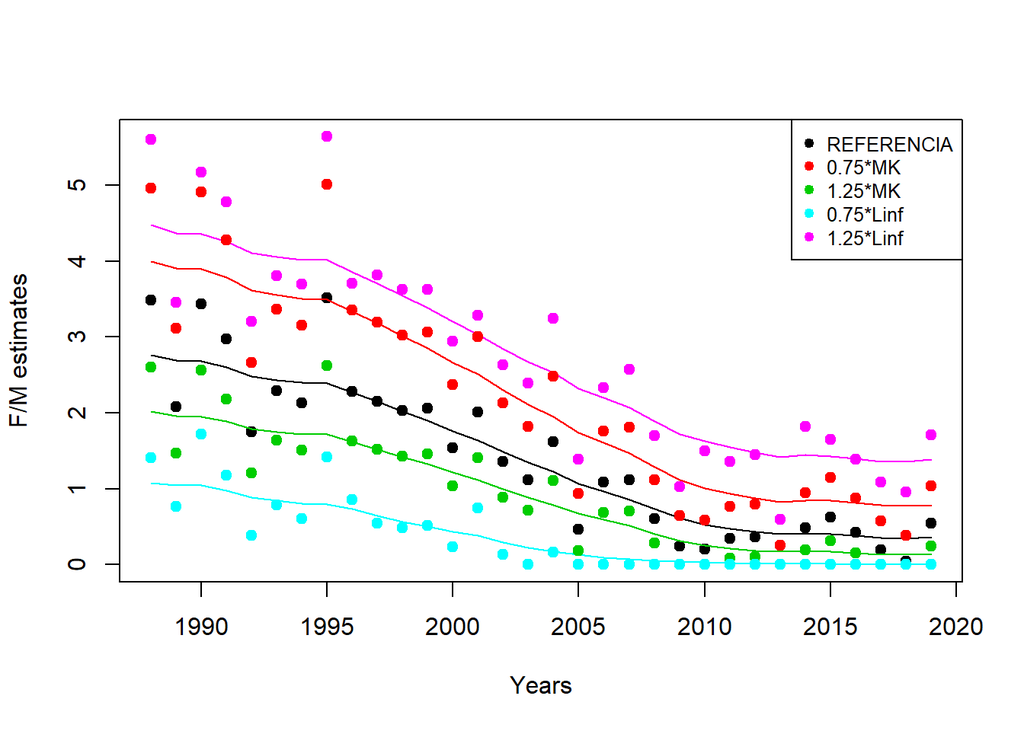

```r
fm1=Fit1@FM
fmmk1=Fit1MK@FM
fmmk2=Fit2MK@FM
fmL1=Fit1Linf@FM
fmL2=Fit2Linf@FM

min=min(c(fm1,fmmk1,fmmk2,fmL1,fmL2))
max=max(c(fm1,fmmk1,fmmk2,fmL1,fmL2))

plot(1988:2019,fm1,ylim=c(min,max),xlab="Years",ylab="F/M estimates",pch=19)

lines(1988:2019, smoothEsts1$FM, lwd = 1,col="black")
lines(1988:2019, smoothEsts1MK$FM, lwd = 1,col=2)
lines(1988:2019, smoothEsts2MK$FM, lwd = 1,col=3)
lines(1988:2019, smoothEsts1Linf$FM, lwd = 1,col=5)
lines(1988:2019, smoothEsts2Linf$FM, lwd = 1,col=6)


points(1988:2019, fmmk1,col=2,pch=19)
points(1988:2019, fmmk2,col=3,pch=19)
points(1988:2019, fmL1,col=5,pch=19)
points(1988:2019, fmL2,col=6,pch=19)

legend("topright", legend=c("REFERENCIA", "0.75*MK","1.25*MK","0.75*Linf","1.25*Linf"),
       col=c("black", c(2,3,5,6)), pch=19, cex=0.8)
```

## 2.2 Nephrops norvegicus FU2627 Females

Life history parameters:

$L_{inf}^{LIT}$ =65 mm ${M/k}^{LIT}$ =2.5 $L_{50}$=26 mm $L_{95}$=29.9 mm

```r
Nepfemales1Pars <- new("LB_pars")
Nepfemales1Pars@Linf <- 65
Nepfemales1Pars@L50 <- 26
Nepfemales1Pars@L95 <- 29.9
Nepfemales1Pars@MK <- 2.5
Nepfemales1Pars@L_units <- "mm"
```

Reference model:

```r
NepfemalesLenFreq1 <- new("LB_lengths", LB_pars=Nepfemales1Pars, file="FU2627_tallasFemales_1988_2019.csv", dataType="freq", header=TRUE)
NepfemalesLenFreq1@L_units <- Nepfemales1Pars@L_units
```

```r
NepfemalesLenFreq1
```

```
## An object of class "LB_lengths"
## Slot "LMids":
##  [1] 12.5 13.5 14.5 15.5 16.5 17.5 18.5 19.5 20.5 21.5 22.5 23.5 24.5 25.5 26.5
## [16] 27.5 28.5 29.5 30.5 31.5 32.5 33.5 34.5 35.5 36.5 37.5 38.5 39.5 40.5 41.5
## [31] 42.5 43.5 44.5 45.5 46.5 47.5 48.5 49.5 50.5 51.5 52.5 53.5 54.5 55.5 56.5
## [46] 57.5 58.5 59.5 60.5 61.5 62.5 63.5 64.5 65.5 66.5 67.5 68.5 69.5 70.5 71.5
## [61] 72.5 73.5 74.5 75.5 76.5 77.5 78.5 79.5 80.5 81.5 82.5 83.5 84.5 85.5 86.5
## [76] 87.5 88.5 89.5 90.5
##
## Slot "LData":
##      1988   1989    1990    1991   1992   1993   1994   1995   1996   1997
## 1       0      0       0       0      0      0      0      0      0      0
## 2       0   4239   15172       0      0      0      0      0      0      0
## 3       0   2474   25480       0      0      0      0      0      0      0
## 4       0 108363   61013    1795      0      0      0      0      0      0
```

[output cut: 249 more lines]

```r
Fit1 <- LBSPRfit(Nepfemales1Pars, NepfemalesLenFreq1,verbose = FALSE)
```

Underestimated ${M/k}^{LIT}$.

```r
Nepfemales1ParsMK <-Nepfemales1Pars
Nepfemales1ParsMK@MK <- 0.75*2.5


NepfemalesLenFreq1MK <- new("LB_lengths", LB_pars=Nepfemales1ParsMK, file="FU2627_tallasFemales_1988_2019.csv", dataType="freq", header=TRUE)
NepfemalesLenFreq1MK@L_units <- Nepfemales1ParsMK@L_units


Fit1MK <- LBSPRfit(Nepfemales1ParsMK, NepfemalesLenFreq1MK, verbose = FALSE)
```

Overestimated ${M/k}^{LIT}$.

```r
Nepfemales2ParsMK <-Nepfemales1Pars
Nepfemales2ParsMK@MK <- 1.25*2.5


NepfemalesLenFreq2MK <- new("LB_lengths", LB_pars=Nepfemales2ParsMK, file="FU2627_tallasFemales_1988_2019.csv", dataType="freq", header=TRUE)
NepfemalesLenFreq2MK@L_units <- Nepfemales2ParsMK@L_units


Fit2MK <- LBSPRfit(Nepfemales2ParsMK, NepfemalesLenFreq2MK,verbose = FALSE)
```

M/k=1.5.

```r
Nepfemales3ParsMK <-Nepfemales1Pars
Nepfemales3ParsMK@MK <- 1.5

NepfemalesLenFreq3MK <- new("LB_lengths", LB_pars=Nepfemales3ParsMK, file="FU2627_tallasFemales_1988_2019.csv", dataType="freq", header=TRUE)
NepfemalesLenFreq3MK@L_units <- Nepfemales3ParsMK@L_units


Fit3MK <- LBSPRfit(Nepfemales3ParsMK, NepfemalesLenFreq3MK,verbose = FALSE)
```

Underestimated $L_{inf}^{LIT}$.

```r
Nepfemales1ParsLinf <-Nepfemales1Pars
Nepfemales1ParsLinf@Linf <- 0.75*65

NepfemalesLenFreq1Linf <- new("LB_lengths", LB_pars=Nepfemales1ParsLinf, file="FU2627_tallasFemales_1988_2019.csv", dataType="freq", header=TRUE)
NepfemalesLenFreq1Linf@L_units <- Nepfemales1ParsLinf@L_units


Fit1Linf <- LBSPRfit(Nepfemales1ParsLinf, NepfemalesLenFreq1Linf,verbose = FALSE)
```

Overestimated $L_{inf}^{LIT}$.

```r
Nepfemales2ParsLinf <-Nepfemales1Pars
Nepfemales2ParsLinf@Linf <- 1.25*65

NepfemalesLenFreq2Linf <- new("LB_lengths", LB_pars=Nepfemales2ParsLinf, file="FU2627_tallasFemales_1988_2019.csv", dataType="freq", header=TRUE)
NepfemalesLenFreq2Linf@L_units <- Nepfemales2ParsLinf@L_units


Fit2Linf <- LBSPRfit(Nepfemales2ParsLinf, NepfemalesLenFreq2Linf,verbose = FALSE)
```

Plots:

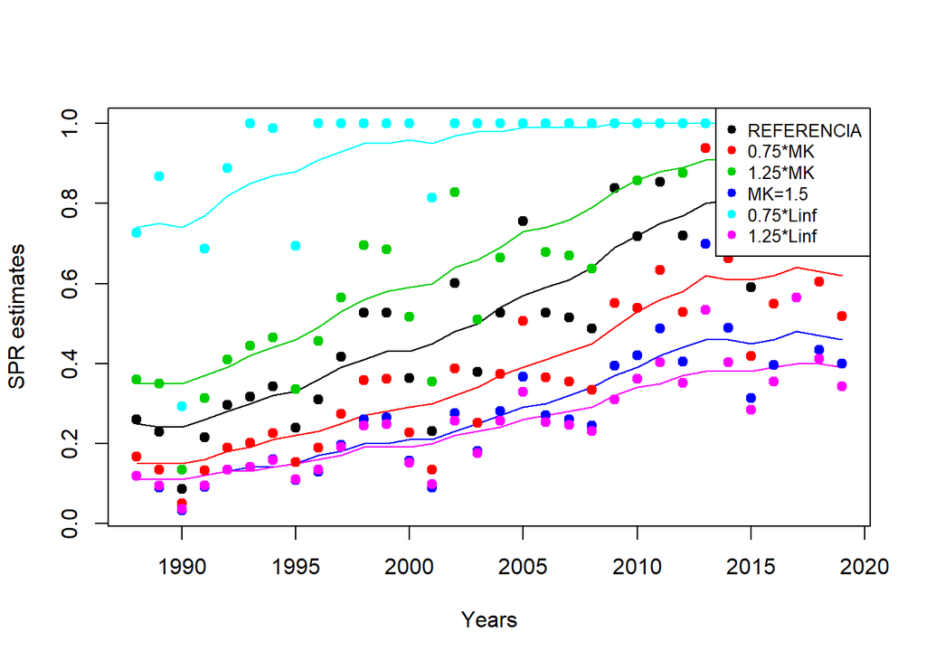

```r
smoothEsts1 <- data.frame(Fit1@Ests)
smoothEsts1MK <- data.frame(Fit1MK@Ests)
smoothEsts2MK <- data.frame(Fit2MK@Ests)
smoothEsts3MK <- data.frame(Fit3MK@Ests)
smoothEsts1Linf <- data.frame(Fit1Linf@Ests)
smoothEsts2Linf <- data.frame(Fit2Linf@Ests)


spr1=Fit1@SPR
sprmk1=Fit1MK@SPR
sprmk2=Fit2MK@SPR
sprmk3=Fit3MK@SPR
sprL1=Fit1Linf@SPR
sprL2=Fit2Linf@SPR

min=min(c(spr1,sprmk1,sprmk2,sprmk3,sprL1,sprL2))
max=max(c(spr1,sprmk1,sprmk2,sprmk3,sprL1,sprL2))

plot(1988:2019,spr1,ylim=c(min,max),xlab="Years",ylab="SPR estimates",pch=19)

lines(1988:2019, smoothEsts1$SPR, lwd = 1,col="black")
lines(1988:2019, smoothEsts1MK$SPR, lwd = 1,col=2)
lines(1988:2019, smoothEsts2MK$SPR, lwd = 1,col=3)
lines(1988:2019, smoothEsts3MK$SPR, lwd = 1,col=4)
lines(1988:2019, smoothEsts1Linf$SPR, lwd = 1,col=5)
lines(1988:2019, smoothEsts2Linf$SPR, lwd = 1,col=6)


points(1988:2019, sprmk1,col=2,pch=19)
points(1988:2019, sprmk2,col=3,pch=19)
points(1988:2019, sprmk3,col=4,pch=19)
points(1988:2019, sprL1,col=5,pch=19)
points(1988:2019, sprL2,col=6,pch=19)

legend("topright", legend=c("REFERENCIA", "0.75*MK","1.25*MK","MK=1.5","0.75*Linf","1.25*Linf"),
       col=c("black", 2:6), pch=19, cex=0.8)
```

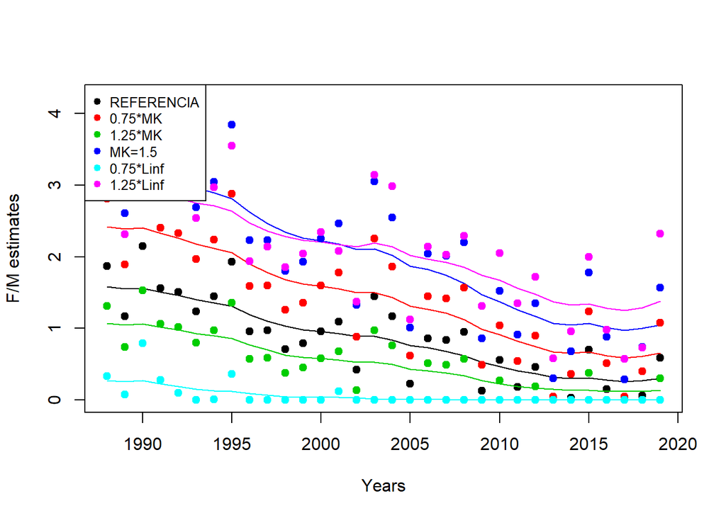

```r
fm1=Fit1@FM
fmmk1=Fit1MK@FM
fmmk2=Fit2MK@FM
fmmk3=Fit3MK@FM
fmL1=Fit1Linf@FM
fmL2=Fit2Linf@FM

min=min(c(fm1,fmmk1,fmmk2,fmmk3,fmL1,fmL2))
max=max(c(fm1,fmmk1,fmmk2,fmmk3,fmL1,fmL2))
plot(1988:2019,fm1,ylim=c(min,max),xlab="Years",ylab="F/M estimates",pch=19)

lines(1988:2019, smoothEsts1$FM, lwd = 1,col="black")
lines(1988:2019, smoothEsts1MK$FM, lwd = 1,col=2)
lines(1988:2019, smoothEsts2MK$FM, lwd = 1,col=3)
lines(1988:2019, smoothEsts3MK$FM, lwd = 1,col=4)
lines(1988:2019, smoothEsts1Linf$FM, lwd = 1,col=5)
lines(1988:2019, smoothEsts2Linf$FM, lwd = 1,col=6)


points(1988:2019, fmmk1,col=2,pch=19)
points(1988:2019, fmmk2,col=3,pch=19)
points(1988:2019, fmmk3,col=4,pch=19)
points(1988:2019, fmL1,col=5,pch=19)
points(1988:2019, fmL2,col=6,pch=19)

legend("topleft", legend=c("REFERENCIA", "0.75*MK","1.25*MK","MK=1.5","0.75*Linf","1.25*Linf"),
       col=c("black", 2:6), pch=19, cex=0.8)
```

# 3 Scyliorhinus canicula

Life history parameters:

$L_{inf}^{LIT}$ = 75 cm ${M/k}^{LIT}$ = 1.5 $L_{50}$=54.2 cm $L_{95}$= 58 cm

```r
PinPars <- new("LB_pars")
PinPars@Linf <- 75
PinPars@L50 <- 54.2
PinPars@L95 <- 58
PinPars@MK <- 1.5
PinPars@L_units <- "cm"
```

Reference model:

```r
PinLenFreq1 <- new("LB_lengths", LB_pars=PinPars, file="Pin8c9afreq.csv", dataType="freq", header=TRUE)
PinLenFreq1@L_units <- PinPars@L_units
PinLenFreq1
```

```
## An object of class "LB_lengths"
## Slot "LMids":
##  [1] 20.5 21.5 22.5 23.5 24.5 25.5 26.5 27.5 28.5 29.5 30.5 31.5 32.5 33.5 34.5
## [16] 35.5 36.5 37.5 38.5 39.5 40.5 41.5 42.5 43.5 44.5 45.5 46.5 47.5 48.5 49.5
## [31] 50.5 51.5 52.5 53.5 54.5 55.5 56.5 57.5 58.5 59.5 60.5 61.5 62.5 63.5 64.5
## [46] 65.5 66.5 67.5 68.5 69.5 70.5 71.5 72.5 73.5 74.5
##
## Slot "LData":
##     2014  2015  2016 2017 2018 2019
## 1    0.0   0.0  0.00  0.0  0.0  0.0
## 2    0.0   0.0  0.00  0.0  0.0  0.0
## 3    0.0   0.0  0.00  0.0  0.0  0.0
## 4    0.0   0.0  0.00  0.0  0.0  0.0
## 5    0.0   0.0  0.00  0.0  0.0  0.0
## 6    0.0   0.0  0.00  0.0  0.0  0.0
```

[output cut: 61 more lines]

```r
Fit1 <- LBSPRfit(PinPars, PinLenFreq1,verbose = FALSE)
```

Underestimated ${M/k}^{LIT}$.

```r
Pin1ParsMK <-PinPars
Pin1ParsMK@MK <- 0.75*1.5
PinLenFreq1MK <- new("LB_lengths", LB_pars=Pin1ParsMK, file="Pin8c9afreq.csv", dataType="freq", header=TRUE)
PinLenFreq1MK@L_units <- Pin1ParsMK@L_units
Fit1MK <- LBSPRfit(Pin1ParsMK, PinLenFreq1MK,verbose = FALSE)
```

Overestimated ${M/k}^{LIT}$.

```r
Pin2ParsMK <-PinPars
Pin2ParsMK@MK <- 1.25*1.5
PinLenFreq2MK <- new("LB_lengths", LB_pars=Pin2ParsMK, file="Pin8c9afreq.csv", dataType="freq", header=TRUE)
PinLenFreq2MK@L_units <- Pin2ParsMK@L_units
Fit2MK <- LBSPRfit(Pin2ParsMK, PinLenFreq2MK,verbose = FALSE)
```

Underestimated $L_{inf}^{LIT}$.

```r
Pin1ParsLinf <-PinPars
Pin1ParsLinf@Linf <- 0.75*75
PinLenFreq1Linf <- new("LB_lengths", LB_pars=Pin1ParsLinf, file="Pin8c9afreq.csv", dataType="freq", header=TRUE)
PinLenFreq1Linf@L_units <- Pin1ParsLinf@L_units
Fit1Linf <- LBSPRfit(Pin1ParsLinf, PinLenFreq1Linf,verbose = FALSE)
```

Overestimated $L_{inf}^{LIT}$.

```r
Pin2ParsLinf <-PinPars
Pin2ParsLinf@Linf <- 1.25*75
PinLenFreq2Linf <- new("LB_lengths", LB_pars=Pin2ParsLinf, file="Pin8c9afreq.csv", dataType="freq", header=TRUE)
PinLenFreq2Linf@L_units <- Pin2ParsLinf@L_units



PinLenFreq2Linf@LMids=seq(20.5,94.5,by=1)
A=PinLenFreq2Linf@LData
for(i in 1:20){
A=rbind(A,(PinLenFreq2Linf@LData[55,]))}
A[55:75,1:6]=rep(0,6)

PinLenFreq2Linf@LData=A
Pin2ParsLinf <-PinPars
Pin2ParsLinf@Linf <-1.25*75
Fit2Linf <- LBSPRfit(Pin2ParsLinf, PinLenFreq2Linf,verbose = FALSE)
```

Plots:

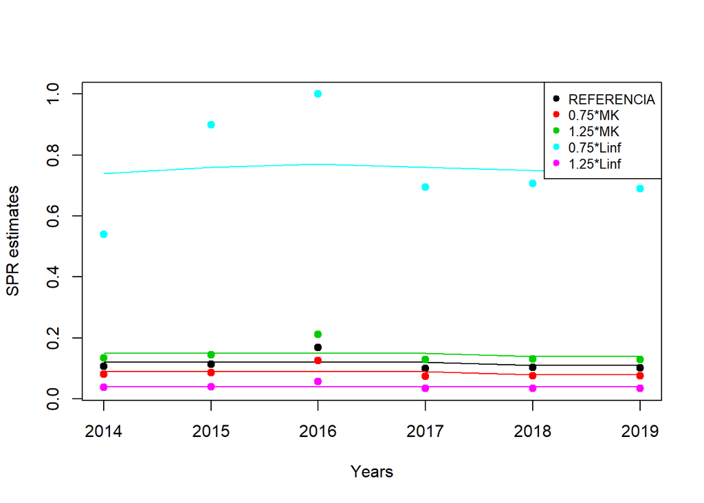

```r
smoothEsts1 <- data.frame(Fit1@Ests)
smoothEsts1MK <- data.frame(Fit1MK@Ests)
smoothEsts2MK <- data.frame(Fit2MK@Ests)
smoothEsts1Linf <- data.frame(Fit1Linf@Ests)
smoothEsts2Linf <- data.frame(Fit2Linf@Ests)

spr1=Fit1@SPR
sprmk1=Fit1MK@SPR
sprmk2=Fit2MK@SPR
sprL1=Fit1Linf@SPR
sprL2=Fit2Linf@SPR

min=min(c(spr1,sprmk1,sprmk2,sprL1,sprL2))
max=max(c(spr1,sprmk1,sprmk2,sprL1,sprL2))

plot(2014:2019,spr1,ylim=c(min,max),xlab="Years",ylab="SPR estimates",pch=19)

lines(2014:2019, smoothEsts1$SPR, lwd = 1,col="black")
lines(2014:2019, smoothEsts1MK$SPR, lwd = 1,col=2)
lines(2014:2019, smoothEsts2MK$SPR, lwd = 1,col=3)
lines(2014:2019, smoothEsts1Linf$SPR, lwd = 1,col=5)
lines(2014:2019, smoothEsts2Linf$SPR, lwd = 1,col=6)

points(2014:2019, sprmk1,col=2,pch=19)
points(2014:2019, sprmk2,col=3,pch=19)
points(2014:2019, sprL1,col=5,pch=19)
points(2014:2019, sprL2,col=6,pch=19)

legend("topright", legend=c("REFERENCIA", "0.75*MK","1.25*MK","0.75*Linf","1.25*Linf"),col=c("black", c(2,3,5,6)), pch=19, cex=0.8)
```

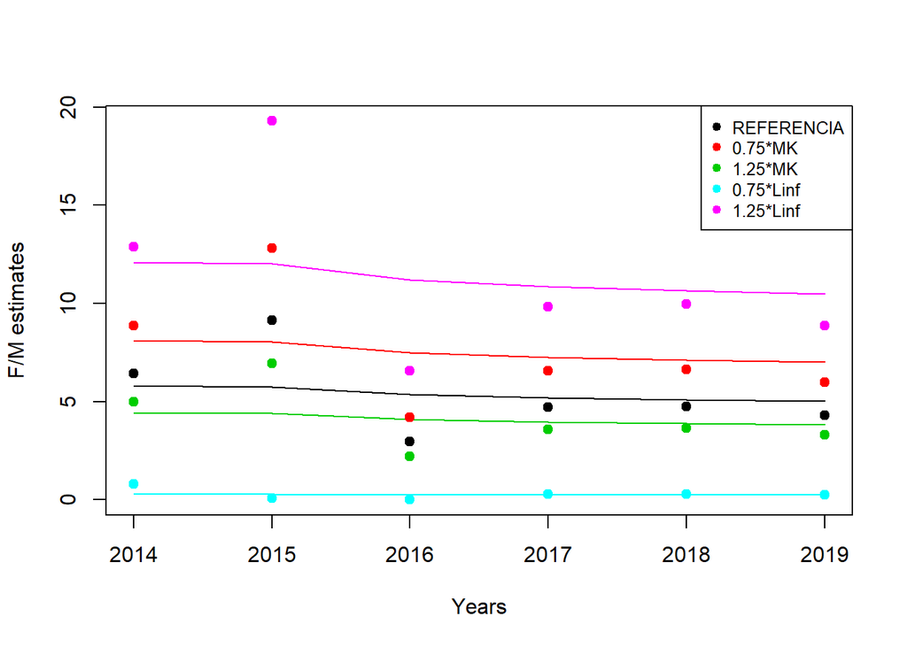

```r
fm1=Fit1@FM
fmmk1=Fit1MK@FM
fmmk2=Fit2MK@FM
fmL1=Fit1Linf@FM
fmL2=Fit2Linf@FM

min=min(c(fm1,fmmk1,fmmk2,fmL1,fmL2))
max=max(c(fm1,fmmk1,fmmk2,fmL1,fmL2))

plot(2014:2019,fm1,ylim=c(min,max),xlab="Years",ylab="F/M estimates",pch=19)

lines(2014:2019, smoothEsts1$FM, lwd = 1,col="black")
lines(2014:2019, smoothEsts1MK$FM, lwd = 1,col=2)
lines(2014:2019, smoothEsts2MK$FM, lwd = 1,col=3)
lines(2014:2019, smoothEsts1Linf$FM, lwd = 1,col=5)
lines(2014:2019, smoothEsts2Linf$FM, lwd = 1,col=6)
points(2014:2019, fmmk1,col=2,pch=19)
points(2014:2019, fmmk2,col=3,pch=19)
points(2014:2019, fmL1,col=5,pch=19)
points(2014:2019, fmL2,col=6,pch=19)

legend("topright", legend=c("REFERENCIA", "0.75*MK","1.25*MK","0.75*Linf","1.25*Linf"),col=c("black", 2,3,5,6), pch=19, cex=0.8)
```

# 4 Engraulis encrasicolus

Life history parameters:

$L_{inf}^{LIT}$ = 18.95 cm ${M/k}^{LIT}$ = 1.44 $L_{50}$=11.2 cm $L_{95}$=13.3 cm

```r
MK<-1.44
LINF<-18.95
Hke1Pars <- new("LB_pars")
Hke1Pars@Linf <- 18.95
Hke1Pars@L50 <- 11.2
Hke1Pars@L95 <- 13.3
Hke1Pars@MK <- 1.44
Hke1Pars@L_units <- "cm"
```

```r
HkeLenFreq1 <- new("LB_lengths", LB_pars=Hke1Pars, file="lengthfreq_anchovy_fv.csv", dataType="freq", header=TRUE)
HkeLenFreq1@L_units <- Hke1Pars@L_units
HkeLenFreq1
```

```
## An object of class "LB_lengths"
## Slot "LMids":
##  [1]  3.75  4.25  4.75  5.25  5.75  6.25  6.75  7.25  7.75  8.25  8.75  9.25
## [13]  9.75 10.25 10.75 11.25 11.75 12.25 12.75 13.25 13.75 14.25 14.75 15.25
## [25] 15.75 16.25 16.75 17.25 17.75 18.25 18.75 19.25 19.75 20.25
##
## Slot "LData":
##        1988     1989      1990     1991     1992     1993     1994     1995
## 1         0        0         0        0        0        0        0        0
## 2         0        0   4281037   171956     1527    48637        0        0
## 3         0        0  18371017  3937228    29018   706893        0        0
## 4     64688        0  32251146 54991246    90023  1831793        0        0
## 5     86251        0  46583672 80536890   368660  3246934        0        0
## 6         0        0  45810220 43303347   983188  5030957        0        0
## 7         0  1185220  44453694 28102013  2685309  6463051  6091799        0
```

[output cut: 181 more lines]

```r
Fit1 <- LBSPRfit(Hke1Pars, HkeLenFreq1,verbose =FALSE)
```

Underestimated ${M/k}^{LIT}$.

```r
Hke1ParsMK <-Hke1Pars
Hke1ParsMK@MK <- 0.75*MK


HkeLenFreq1MK <- new("LB_lengths", LB_pars=Hke1ParsMK, file="lengthfreq_anchovy_fv.csv", dataType="freq", header=TRUE)
HkeLenFreq1MK@L_units <- Hke1ParsMK@L_units


Fit1MK <- LBSPRfit(Hke1ParsMK, HkeLenFreq1MK,verbose = FALSE)
```

Overestimated ${M/k}^{LIT}$.

```r
Hke2ParsMK <-Hke1Pars
Hke2ParsMK@MK <- 1.25*MK


HkeLenFreq2MK <- new("LB_lengths", LB_pars=Hke2ParsMK, file="lengthfreq_anchovy_fv.csv", dataType="freq", header=TRUE)
HkeLenFreq2MK@L_units <- Hke2ParsMK@L_units


Fit2MK <- LBSPRfit(Hke2ParsMK, HkeLenFreq2MK,verbose = FALSE)
```

M/k=1.5.

```r
Hke3ParsMK <-Hke1Pars
Hke3ParsMK@MK <- 1.5

HkeLenFreq3MK <- new("LB_lengths", LB_pars=Hke3ParsMK, file="lengthfreq_anchovy_fv.csv", dataType="freq", header=TRUE)
HkeLenFreq3MK@L_units <- Hke3ParsMK@L_units


Fit3MK <- LBSPRfit(Hke3ParsMK, HkeLenFreq3MK,verbose = FALSE)
```

Underestimated $L_{inf}^{LIT}$.

```r
Hke1ParsLinf <-Hke1Pars
Hke1ParsLinf@Linf <- 0.75*LINF

HkeLenFreq1Linf <- new("LB_lengths", LB_pars=Hke1ParsLinf, file="lengthfreq_anchovy_fv.csv", dataType="freq", header=TRUE)
HkeLenFreq1Linf@L_units <- Hke1ParsLinf@L_units


Fit1Linf <- LBSPRfit(Hke1ParsLinf, HkeLenFreq1Linf,verbose = FALSE)
```

Overestimated $L_{inf}^{LIT}$.

```r
Hke2ParsLinf <-Hke1Pars
Hke2ParsLinf@Linf <- 1.25*LINF

HkeLenFreq2Linf <- new("LB_lengths", LB_pars=Hke2ParsLinf, file="lengthfreq_anchovy_fv.csv", dataType="freq", header=TRUE)
HkeLenFreq2Linf@L_units <- Hke2ParsLinf@L_units
HkeLenFreq2Linf@LMids=seq(3.75,23.75,0.5)
rows2add<-length(HkeLenFreq2Linf@LMids)-dim(HkeLenFreq2Linf@LData)[1]
B<-array(0,dim=c(rows2add,dim(HkeLenFreq2Linf@LData)[2]))
A=rbind(HkeLenFreq2Linf@LData,B)

HkeLenFreq2Linf@LData=A

Fit2Linf <- LBSPRfit(Hke2ParsLinf, HkeLenFreq2Linf,verbose = FALSE)
```

Plots:

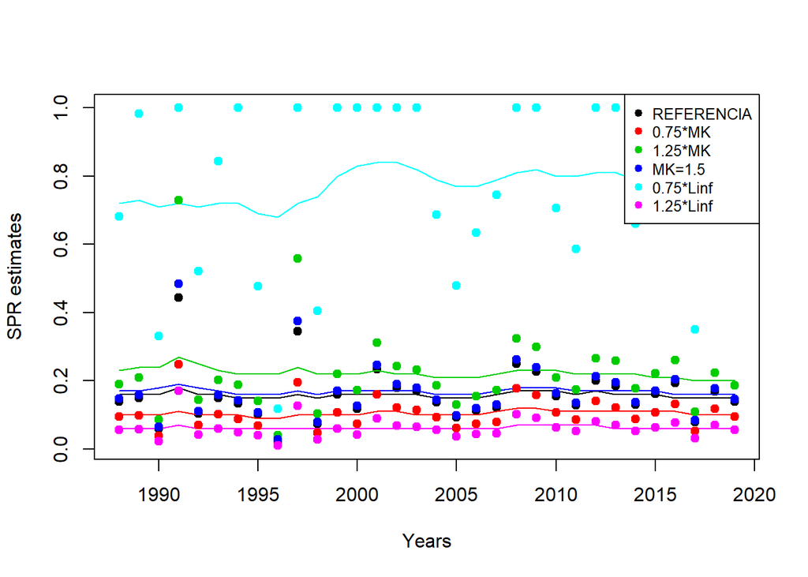

```r
smoothEsts1 <- data.frame(Fit1@Ests)
smoothEsts1MK <- data.frame(Fit1MK@Ests)
smoothEsts2MK <- data.frame(Fit2MK@Ests)
smoothEsts3MK <- data.frame(Fit3MK@Ests)
smoothEsts1Linf <- data.frame(Fit1Linf@Ests)
smoothEsts2Linf <- data.frame(Fit2Linf@Ests)


spr1=Fit1@SPR
sprmk1=Fit1MK@SPR
sprmk2=Fit2MK@SPR
sprmk3=Fit3MK@SPR
sprL1=Fit1Linf@SPR
sprL2=Fit2Linf@SPR

min=min(c(spr1,sprmk1,sprmk2,sprL1,sprL2))
max=max(c(spr1,sprmk1,sprmk2,sprL1,sprL2))

plot(HkeLenFreq2Linf@Years[1]:HkeLenFreq2Linf@Years[32],spr1,ylim=c(min,max),xlab="Years",ylab="SPR estimates",pch=19)

lines(HkeLenFreq2Linf@Years[1]:HkeLenFreq2Linf@Years[32], smoothEsts1$SPR, lwd = 1,col="black")
lines(HkeLenFreq2Linf@Years[1]:HkeLenFreq2Linf@Years[32], smoothEsts1MK$SPR, lwd = 1,col=2)
lines(HkeLenFreq2Linf@Years[1]:HkeLenFreq2Linf@Years[32], smoothEsts2MK$SPR, lwd = 1,col=3)
lines(HkeLenFreq2Linf@Years[1]:HkeLenFreq2Linf@Years[32], smoothEsts3MK$SPR, lwd = 1,col=4)
lines(HkeLenFreq2Linf@Years[1]:HkeLenFreq2Linf@Years[32], smoothEsts1Linf$SPR, lwd = 1,col=5)
lines(HkeLenFreq2Linf@Years[1]:HkeLenFreq2Linf@Years[32], smoothEsts2Linf$SPR, lwd = 1,col=6)


points(HkeLenFreq2Linf@Years[1]:HkeLenFreq2Linf@Years[32], sprmk1,col=2,pch=19)
points(HkeLenFreq2Linf@Years[1]:HkeLenFreq2Linf@Years[32], sprmk2,col=3,pch=19)
points(HkeLenFreq2Linf@Years[1]:HkeLenFreq2Linf@Years[32], sprmk3,col=4,pch=19)
points(HkeLenFreq2Linf@Years[1]:HkeLenFreq2Linf@Years[32], sprL1,col=5,pch=19)
points(HkeLenFreq2Linf@Years[1]:HkeLenFreq2Linf@Years[32], sprL2,col=6,pch=19)

legend("topright", legend=c("REFERENCIA", "0.75*MK","1.25*MK","MK=1.5","0.75*Linf","1.25*Linf"),
       col=c("black", 2:6), pch=19, cex=0.8)
```

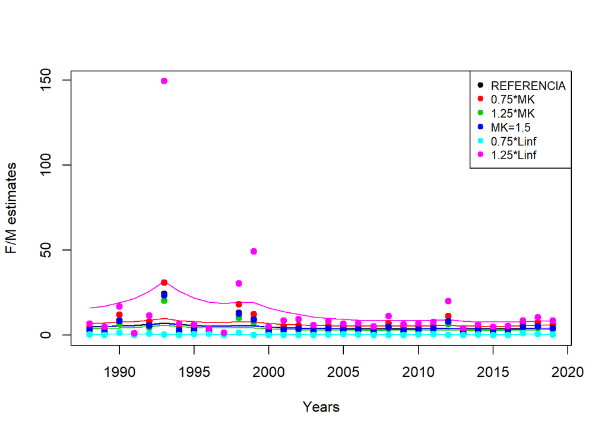

```r
fm1=Fit1@FM
fmmk1=Fit1MK@FM
fmmk2=Fit2MK@FM
fmmk3=Fit3MK@FM
fmL1=Fit1Linf@FM
fmL2=Fit2Linf@FM

min=min(c(fm1,fmmk1,fmmk2,fmL1,fmL2))
max=max(c(fm1,fmmk1,fmmk2,fmL1,fmL2))

plot(HkeLenFreq2Linf@Years[1]:HkeLenFreq2Linf@Years[32],fm1,ylim=c(min,max),xlab="Years",ylab="F/M estimates",pch=19)

lines(HkeLenFreq2Linf@Years[1]:HkeLenFreq2Linf@Years[32], smoothEsts1$FM, lwd = 1,col="black")
lines(HkeLenFreq2Linf@Years[1]:HkeLenFreq2Linf@Years[32], smoothEsts1MK$FM, lwd = 1,col=2)
lines(HkeLenFreq2Linf@Years[1]:HkeLenFreq2Linf@Years[32], smoothEsts2MK$FM, lwd = 1,col=3)
lines(HkeLenFreq2Linf@Years[1]:HkeLenFreq2Linf@Years[32], smoothEsts3MK$FM, lwd = 1,col=4)
lines(HkeLenFreq2Linf@Years[1]:HkeLenFreq2Linf@Years[32], smoothEsts1Linf$FM, lwd = 1,col=5)
lines(HkeLenFreq2Linf@Years[1]:HkeLenFreq2Linf@Years[32], smoothEsts2Linf$FM, lwd = 1,col=6)


points(HkeLenFreq2Linf@Years[1]:HkeLenFreq2Linf@Years[32], fmmk1,col=2,pch=19)
points(HkeLenFreq2Linf@Years[1]:HkeLenFreq2Linf@Years[32], fmmk2,col=3,pch=19)
points(HkeLenFreq2Linf@Years[1]:HkeLenFreq2Linf@Years[32], fmmk3,col=4,pch=19)
points(HkeLenFreq2Linf@Years[1]:HkeLenFreq2Linf@Years[32], fmL1,col=5,pch=19)
points(HkeLenFreq2Linf@Years[1]:HkeLenFreq2Linf@Years[32], fmL2,col=6,pch=19)

legend("topright", legend=c("REFERENCIA", "0.75*MK","1.25*MK","MK=1.5","0.75*Linf","1.25*Linf"),
       col=c("black", 2:6), pch=19, cex=0.8)
```

# 5 Pollachius pollachius

Life history parameters:

$L_{inf}^{LIT}$ = 98.2 cm ${M/k}^{LIT}$ =1.648352 $L_{50}$= 42.3 cm $L_{95}$= 59 cm

```r
Pol1 <- new("LB_pars")
Pol1@Linf <- 98.2
Pol1@L50 <- 42.3
Pol1@L95 <- 59
Pol1@MK <- 0.3/0.182
Pol1@L_units <- "cm"
```

Reference model:

```r
Len1 <- new("LB_lengths", LB_pars=Pol1, file=("pol89aSPR_MultYr4cm.csv"), dataType="freq",header=TRUE)
Len1
```

```
## An object of class "LB_lengths"
## Slot "LMids":
##  [1]   2   6  10  14  18  22  26  30  34  38  42  46  50  54  58  62  66  70  74
## [20]  78  82  86  90  94  98 102 106 110 114 118 122 126 130
##
## Slot "LData":
##       2010    2011    2012    2013    2014    2015    2016    2017    2018
## 1    0.000   0.000   0.000   0.000   0.000   0.000   0.000   0.000   0.000
## 2    0.000   0.000   0.000   0.000   0.000   0.000   0.000   0.000   0.000
## 3    0.000   0.000   0.000   0.000   0.000   0.000   0.000   0.000   0.000
## 4    0.000   0.000   0.000   0.000   0.000   0.000   0.000   1.130   0.000
## 5    0.000   0.000   0.000   0.000   0.000   4.862   0.000  12.429   0.000
## 6    0.000   0.000   0.000   0.000   0.000   9.724   0.000  40.678   0.000
## 7    0.000   2.271   0.000   0.000   0.000  95.528   0.294  16.374   0.478
## 8   40.304   8.222   0.000   0.838   0.000 236.941  22.888  43.118  44.600
```

[output cut: 71 more lines]

```r
Fit1 <- LBSPRfit(Pol1, Len1,verbose = FALSE)
```

Underestimated ${M/k}^{LIT}$.

```r
Pol0.75MK <- Pol1
Pol0.75MK@MK <- 0.75*Pol1@MK
Pol0.75LenMK <- new("LB_lengths",  LB_pars=Pol0.75MK, file="pol89aSPR_MultYr4cm.csv", dataType="freq", header=TRUE)
Pol0.75LenMK@L_units <- Pol0.75MK@L_units
Fit0.75MK <- LBSPRfit(Pol0.75MK, Pol0.75LenMK,verbose = FALSE)
```

Overestimated ${M/k}^{LIT}$.

```r
Pol1.25MK <- Pol1
Pol1.25MK@MK <- 1.25*Pol1@MK
Pol1.25LenMK <- new("LB_lengths", LB_pars=Pol1.25MK, file="pol89aSPR_MultYr4cm.csv", dataType="freq", header=TRUE)
Pol1.25LenMK@L_units <- Pol1.25MK@L_units
Fit1.25MK <- LBSPRfit(Pol1.25MK, Pol1.25LenMK,verbose = FALSE)
```

M/k=1.5.

```r
Pol1.5MK <- Pol1
Pol1.5MK@MK <- 1.5
Pol1.5LenMK <- new("LB_lengths", LB_pars=Pol1.5MK, file="pol89aSPR_MultYr4cm.csv", dataType="freq", header=TRUE)
Pol1.5LenMK@L_units <- Pol1.5MK@L_units
Fit1.5MK <- LBSPRfit(Pol1.5MK, Pol1.5LenMK,verbose = FALSE)
```

Underestimated $L_{inf}^{LIT}$.

```r
Pol0.75Linf <- Pol1
Pol0.75Linf@Linf <- 0.75*Pol1@Linf
Pol0.75LenLinf <- new("LB_lengths", LB_pars=Pol0.75Linf, file="pol89aSPR_MultYr4cm.csv", dataType="freq", header=TRUE)
Pol0.75LenLinf@L_units <- Pol0.75Linf@L_units
Fit0.75Linf <- LBSPRfit(Pol0.75Linf, Pol0.75LenLinf,verbose = FALSE)
```

Overestimated $L_{inf}^{LIT}$.

```r
Pol1.25Linf <- Pol1
Pol1.25Linf@Linf <- 1.25*Pol1@Linf
Pol1.25LenLinf <- new("LB_lengths", LB_pars=Pol1.25Linf, file="pol89aSPR_MultYr4cm.csv", dataType="freq", header=TRUE)
Pol1.25LenLinf@L_units <- Pol1.25Linf@L_units
Fit1.25Linf <- LBSPRfit(Pol1.25Linf, Pol1.25LenLinf,verbose = FALSE)
```

Plots:

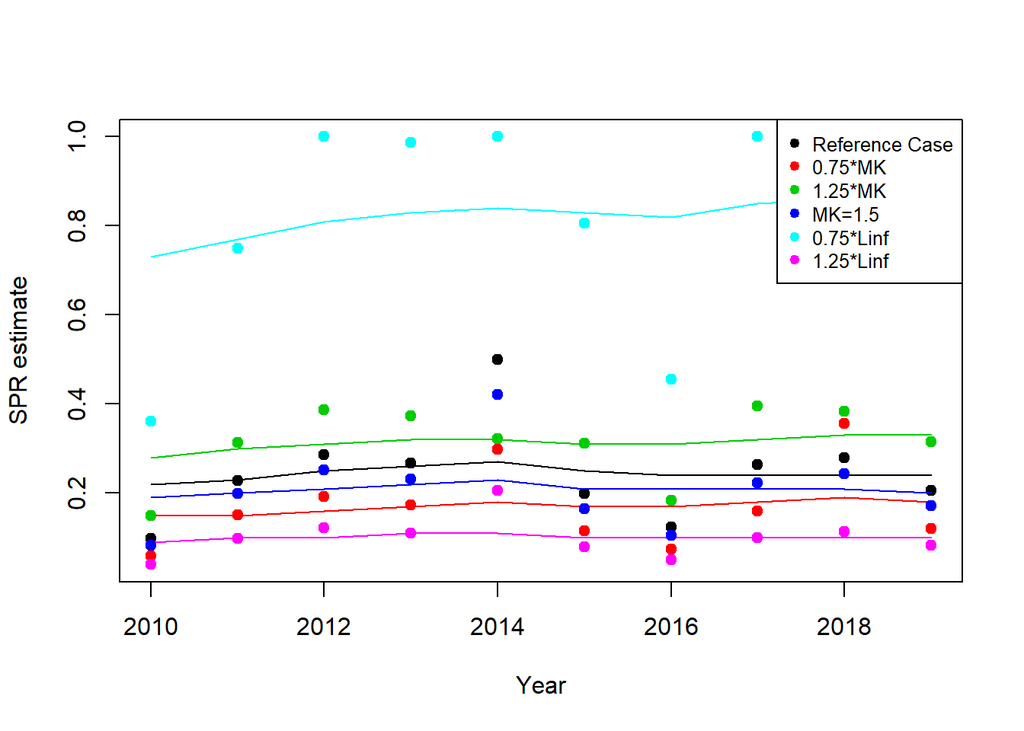

```r
smoothEsts1 <- data.frame(Fit1@Ests)
smoothEsts1MK <- data.frame(Fit0.75MK@Ests)
smoothEsts2MK <- data.frame(Fit1.25MK@Ests)
smoothEsts3MK <- data.frame(Fit1.5MK@Ests)
smoothEsts1Linf <- data.frame(Fit0.75Linf@Ests)
smoothEsts2Linf <- data.frame(Fit1.25Linf@Ests)

spr1 <- Fit1@SPR
sprmk1 <- Fit0.75MK@SPR
sprmk2 <- Fit1.25MK@SPR
sprmk3 <- Fit1.5MK@SPR
sprL1 <- Fit0.75Linf@SPR
sprL2 <- Fit1.25Linf@SPR

min=min(c(spr1,sprmk1,sprmk2,sprL1,sprL2))
max=max(c(spr1,sprmk1,sprmk2,sprL1,sprL2))

plot(c(2010:2019),spr1,ylim=c(min,max),xlab="Year",ylab="SPR estimate",pch=19)

lines(2010:2019, smoothEsts1$SPR, lwd = 1,col="black")
lines(2010:2019, smoothEsts1MK$SPR, lwd = 1, col=2)
lines(2010:2019, smoothEsts2MK$SPR, lwd = 1, col=3)
lines(2010:2019, smoothEsts3MK$SPR, lwd = 1, col=4)
lines(2010:2019, smoothEsts1Linf$SPR, lwd = 1, col=5)
lines(2010:2019, smoothEsts2Linf$SPR, lwd = 1 ,col=6)


points(2010:2019, sprmk1,col=2,pch=19)
points(2010:2019, sprmk2,col=3,pch=19)
points(2010:2019, sprmk3,col=4,pch=19)
points(2010:2019, sprL1,col=5,pch=19)
points(2010:2019, sprL2,col=6, pch=19)

legend("topright", legend=c("Reference Case", "0.75*MK","1.25*MK","MK=1.5","0.75*Linf","1.25*Linf"),
       col=c("black", 2:6), pch=19, cex=0.8)
```

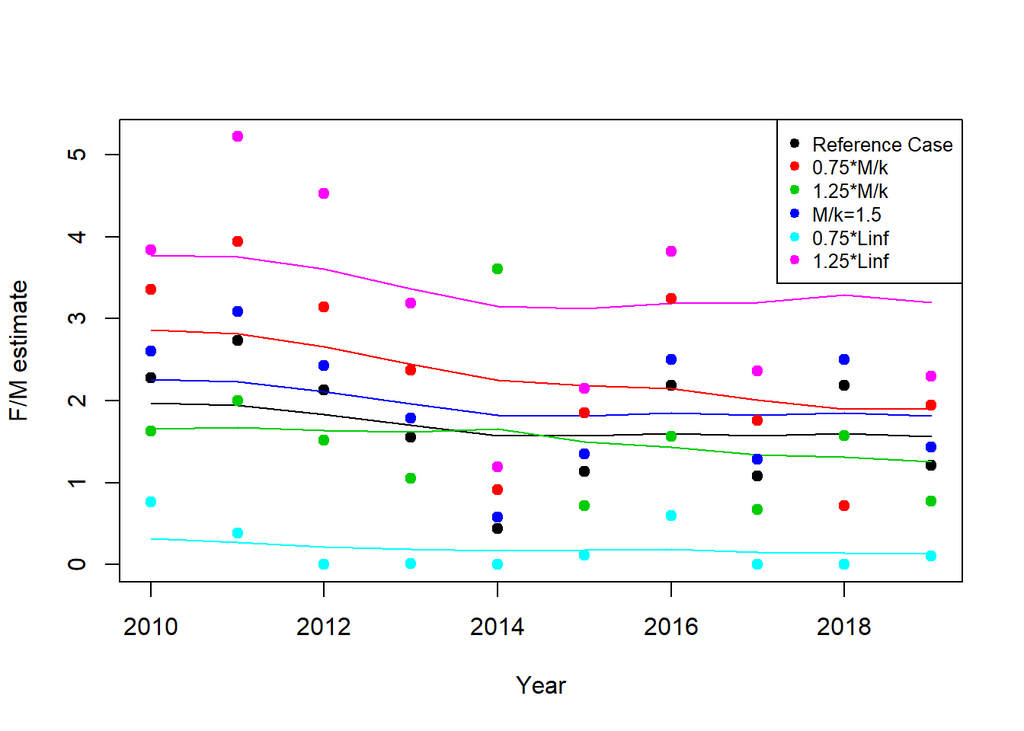

```r
fm1=Fit1@FM
fmmk1=Fit0.75MK@FM
fmmk2=Fit1.25MK@FM
fmmk3=Fit1.5MK@FM
fmL1=Fit0.75Linf@FM
fmL2=Fit1.25Linf@FM

min=min(c(fm1,fmmk1,fmmk2,fmL1,fmL2))
max=max(c(fm1,fmmk1,fmmk2,fmL1,fmL2))

plot(2010:2019,fm1,ylim=c(min,max),xlab="Year",ylab="F/M estimate",pch=19)

lines(2010:2019, smoothEsts1$FM, lwd = 1,col="black")
lines(2010:2019, smoothEsts1MK$FM, lwd = 1,col=2)
lines(2010:2019, smoothEsts2MK$FM, lwd = 1,col=3)
lines(2010:2019, smoothEsts3MK$FM, lwd = 1,col=4)
lines(2010:2019, smoothEsts1Linf$FM, lwd = 1, col=5)
lines(2010:2019, smoothEsts2Linf$FM, lwd = 1, col=6)


points(2010:2019, fmmk1,col=2,pch=19)
points(2010:2019, fmmk2,col=3,pch=19)
points(2010:2019, fmmk3,col=4,pch=19)
points(2010:2019, fmL1,col=5,pch=19)
points(2010:2019, fmL2,col=6,pch=19)
legend("topright", legend=c("Reference Case", "0.75*M/k","1.25*M/k","M/k=1.5","0.75*Linf","1.25*Linf"),
       col=c("black", 2:6), pch=19, cex=0.8)
```

# 6 Pagellus bogaraveo

Life history parameters:

$L_{inf}^{LIT}$ = 62 cm ${M/k}^{LIT}$ = 1.42 $L_{50}$= 33 cm $L_{95}$= 35 cm

```r
sbr1Pars <- new("LB_pars")
sbr1Pars@Linf <- 62
sbr1Pars@L50 <- 33
sbr1Pars@L95 <- 35
sbr1Pars@MK <- 1.42
sbr1Pars@L_units <- "cm"
```

Reference model:

```r
sbrLenFreq1 <- new("LB_lengths", LB_pars=sbr1Pars, file="LFreqSBR.csv", dataType="freq", header=TRUE)
sbrLenFreq1@L_units <- sbr1Pars@L_units
sbrLenFreq1
```

```
## An object of class "LB_lengths"
## Slot "LMids":
##  [1] 24.5 25.5 26.5 27.5 28.5 29.5 30.5 31.5 32.5 33.5 34.5 35.5 36.5 37.5 38.5
## [16] 39.5 40.5 41.5 42.5 43.5 44.5 45.5 46.5 47.5 48.5 49.5 50.5 51.5 52.5 53.5
## [31] 54.5 55.5 56.5 57.5 58.5 59.5 60.5 61.5 62.5 63.5 64.5 65.5 66.5 67.5 68.5
## [46] 69.5 70.5 71.5 72.5 73.5 74.5 75.5 76.5 77.5 78.5
##
## Slot "LData":
##     1997  1998  1999  2000  2001  2002  2003  2004  2005  2006  2007  2008
## 1    422   170     0     0     0     0     0     0     0     0     0     0
## 2   1553   718     0     0     0     0     0     0     0     0     0     0
## 3   9222  6454   527    48    42    91    52     0     0     0     0     0
## 4  33437 25121  2840   717   912   376   599     0  1012  1583   138     0
## 5  69291 53905  9521  3875  3214  2266  3516   254  7417 11301  1224   160
## 6  81193 66854 13037 11083 11024  8050 10162  2416 15187 27559  9655  6810
```

[output cut: 118 more lines]

```r
Fit1 <- LBSPRfit(sbr1Pars, sbrLenFreq1,verbose = FALSE)
```

Underestimated ${M/k}^{LIT}$.

```r
sbr1ParsMK <-sbr1Pars
sbr1ParsMK@MK <- 0.75*1.42

sbrLenFreq1MK <- new("LB_lengths", LB_pars=sbr1ParsMK, file="LFreqSBR.csv", dataType="freq", header=TRUE)
sbrLenFreq1MK@L_units <- sbr1ParsMK@L_units

Fit1MK <- LBSPRfit(sbr1ParsMK, sbrLenFreq1MK,verbose = FALSE)
```

Overestimated ${M/k}^{LIT}$.

```r
sbr2ParsMK <-sbr1Pars
sbr2ParsMK@MK <- 1.25*1.42

sbrLenFreq2MK <- new("LB_lengths", LB_pars=sbr2ParsMK, file="LFreqSBR.csv", dataType="freq", header=TRUE)
sbrLenFreq2MK@L_units <- sbr2ParsMK@L_units

Fit2MK <- LBSPRfit(sbr2ParsMK, sbrLenFreq2MK,verbose = FALSE)
```

M/k=1.5.

```r
sbr3ParsMK <-sbr1Pars
sbr3ParsMK@MK <- 1.5

sbrLenFreq3MK <- new("LB_lengths", LB_pars=sbr3ParsMK, file="LFreqSBR.csv", dataType="freq", header=TRUE)
sbrLenFreq3MK@L_units <- sbr3ParsMK@L_units

Fit3MK <- LBSPRfit(sbr3ParsMK, sbrLenFreq3MK,verbose = FALSE)
```

Underestimated $L_{inf}^{LIT}$.

```r
sbr1ParsLinf <-sbr1Pars
sbr1ParsLinf@Linf <- 62*0.75

sbrLenFreq1Linf <- new("LB_lengths", LB_pars=sbr1ParsLinf, file="LFreqSBR.csv", dataType="freq", header=TRUE)
sbrLenFreq1Linf@L_units <- sbr1ParsLinf@L_units

Fit1Linf <- LBSPRfit(sbr1ParsLinf, sbrLenFreq1Linf,verbose = FALSE)
```

Overestimated $L_{inf}^{LIT}$.

```r
sbr2ParsLinf <-sbr1Pars
sbr2ParsLinf@Linf <- 62*1.25

sbrLenFreq2Linf <- new("LB_lengths", LB_pars=sbr2ParsLinf, file="LFreqSBR.csv", dataType="freq", header=TRUE)
sbrLenFreq2Linf@L_units <- sbr2ParsLinf@L_units

Fit2Linf <- LBSPRfit(sbr2ParsLinf, sbrLenFreq2Linf,verbose = FALSE)
```

Plots:

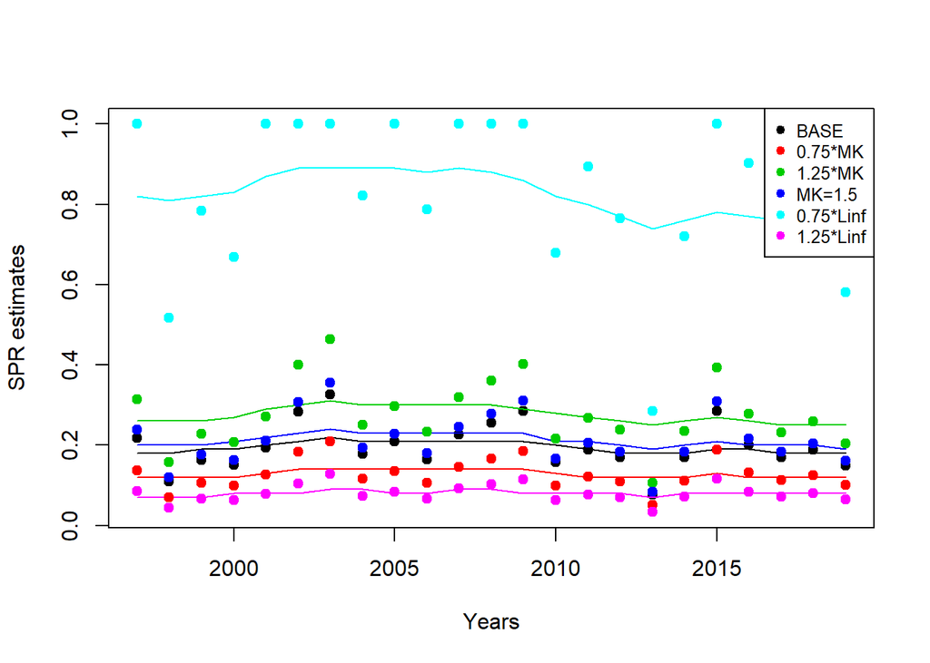

```r
smoothEsts1 <- data.frame(Fit1@Ests)
smoothEsts1MK <- data.frame(Fit1MK@Ests)
smoothEsts2MK <- data.frame(Fit2MK@Ests)
smoothEsts3MK <- data.frame(Fit3MK@Ests)
smoothEsts1Linf <- data.frame(Fit1Linf@Ests)
smoothEsts2Linf <- data.frame(Fit2Linf@Ests)

spr1=Fit1@SPR
sprmk1=Fit1MK@SPR
sprmk2=Fit2MK@SPR
sprmk3=Fit3MK@SPR
sprL1=Fit1Linf@SPR
sprL2=Fit2Linf@SPR

min=min(c(spr1,sprmk1,sprmk2,sprmk3,sprL1,sprL2))
max=max(c(spr1,sprmk1,sprmk2,sprmk3,sprL1,sprL2))

plot(1997:2019,spr1,ylim=c(min,max),xlab="Years",ylab="SPR estimates",pch=19)

lines(1997:2019, smoothEsts1$SPR, lwd = 1,col="black")
lines(1997:2019, smoothEsts1MK$SPR, lwd = 1,col=2)
lines(1997:2019, smoothEsts2MK$SPR, lwd = 1,col=3)
lines(1997:2019, smoothEsts3MK$SPR, lwd = 1,col=4)
lines(1997:2019, smoothEsts1Linf$SPR, lwd = 1,col=5)
lines(1997:2019, smoothEsts2Linf$SPR, lwd = 1,col=6)

points(1997:2019, sprmk1,col=2,pch=19)
points(1997:2019, sprmk2,col=3,pch=19)
points(1997:2019, sprmk3,col=4,pch=19)
points(1997:2019, sprL1,col=5,pch=19)
points(1997:2019, sprL2,col=6,pch=19)

legend("topright", legend=c("BASE", "0.75*MK","1.25*MK","MK=1.5","0.75*Linf","1.25*Linf"),
       col=c("black", 2:6), pch=19, cex=0.8)
```

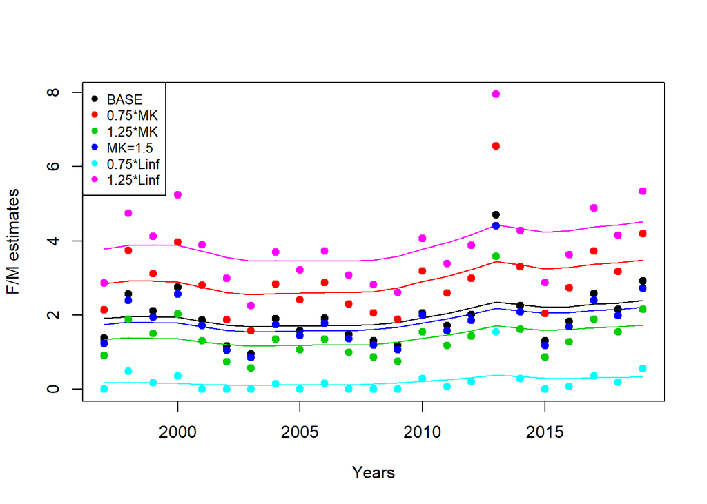

```r
fm1=Fit1@FM
fmmk1=Fit1MK@FM
fmmk2=Fit2MK@FM
fmmk3=Fit3MK@FM
fmL1=Fit1Linf@FM
fmL2=Fit2Linf@FM

min=min(c(fm1,fmmk1,fmmk2,fmmk3,fmL1,fmL2))
max=max(c(fm1,fmmk1,fmmk2,fmmk3,fmL1,fmL2))

plot(1997:2019,fm1,ylim=c(min,max),xlab="Years",ylab="F/M estimates",pch=19)

lines(1997:2019, smoothEsts1$FM, lwd = 1,col="black")
lines(1997:2019, smoothEsts1MK$FM, lwd = 1,col=2)
lines(1997:2019, smoothEsts2MK$FM, lwd = 1,col=3)
lines(1997:2019, smoothEsts3MK$FM, lwd = 1,col=4)
lines(1997:2019, smoothEsts1Linf$FM, lwd = 1,col=5)
lines(1997:2019, smoothEsts2Linf$FM, lwd = 1,col=6)

points(1997:2019, fmmk1,col=2,pch=19)
points(1997:2019, fmmk2,col=3,pch=19)
points(1997:2019, fmmk3,col=4,pch=19)
points(1997:2019, fmL1,col=5,pch=19)
points(1997:2019, fmL2,col=6,pch=19)

legend("topleft", legend=c("BASE", "0.75*MK","1.25*MK","MK=1.5","0.75*Linf","1.25*Linf"),
       col=c("black", 2:6), pch=19, cex=0.8)
```

# 7 Trisopterus luscus

Life history parameters:

$L_{inf}^{LIT}$ = 46.7 cm ${M/k}^{LIT}$ = 1.76 $L_{50}$= 19.2 cm $L_{95}$= 21.43 cm

```r
library(tidyverse)
library(lubridate)
library(kableExtra)
library(knitr)
MyPars <- new("LB_pars")
MyPars@Species <- "Trisopterus luscus"

LHTs <- data.frame(t(c("Trisopterus luscus", 19.2, 1, 46.7, 0.21, 1.27, 9)))
colnames(LHTs) <- c("Sp", "L50", "Amat", "Linf", "K", "t0", "Amax")
LHTs$MKlit1 <-3.111105
LHTs$MKlit2 <- 1.761846
LHTs$MK <- 1.5

a <- -25.77
b <- 1.34
L95 <- (log(0.95/0.05)-a)/b

MyPars@Linf <- as.numeric(as.character(LHTs$Linf))
MyPars@L50  <- as.numeric(as.character(LHTs$L50 ))
MyPars@L95  <- L95
MyPars@MK   <- as.numeric(as.character(LHTs$MKlit2))
MyPars@L_units <- "cm"
```

Reference model:

```r
MyLengths <- new("LB_lengths", LB_pars=MyPars, file="pouting.csv",
                 dataType="freq", header = TRUE)
MyLengths
```

```
## An object of class "LB_lengths"
## Slot "LMids":
##  [1] 10.5 11.5 12.5 13.5 14.5 15.5 16.5 17.5 18.5 19.5 20.5 21.5 22.5 23.5 24.5
## [16] 25.5 26.5 27.5 28.5 29.5 30.5 31.5 32.5 33.5 34.5 35.5 36.5 37.5 38.5 39.5
## [31] 40.5 41.5 42.5 43.5 44.5 45.5 46.5 47.5 48.5 49.5 50.5 51.5 52.5 53.5 54.5
## [46] 55.5 56.5 57.5 58.5
##
## Slot "LData":
##    1999 2000 2001 2002 2003 2004 2005 2006 2007 2008 2009 2010 2011 2012 2013
## 1     0    0    0    0    0    1    0    0    0    0    0    0    0    0    0
## 2     0    0    0    0    0    1    0    0    0    0    0    0    0    0    0
## 3     0    0    1    0    0    0    0    0    0    0    0    0    0    0    0
## 4     0    0    0    2    1    1    0    2    4    2    0    0    1    0    0
## 5     0    2    5    5    2    2    1    2   12    1    1    1    0    0    2
## 6     0    0    8    3   14    2   10    2   18    0    3    1    6    1    3
```

[output cut: 106 more lines]

```r
myFit <- LBSPRfit(MyPars, MyLengths,verbose = FALSE)
```

Underestimated ${M/k}^{LIT}$.

```r
MyParsMKLow <- MyPars
MyParsMKLow@MK <- 0.75*MyPars@MK
MyLengthsMKLow <- new("LB_lengths", LB_pars=MyParsMKLow, file="faneca.csv",
                 dataType="raw", header = TRUE)
MyLengthsMKLow@L_units <- MyParsMKLow@L_units
myFitMKLow <- LBSPRfit(MyParsMKLow, MyLengthsMKLow,verbose = FALSE)
```

Overestimated ${M/k}^{LIT}$.

```r
MyParsMKSup <- MyPars
MyParsMKSup@MK <- 1.25*MyPars@MK
MyLengthsMKSup <- new("LB_lengths", LB_pars=MyParsMKSup, file="faneca.csv",
                     dataType="raw", header = TRUE)
MyLengthsMKSup@L_units <- MyParsMKSup@L_units
myFitMKSup <- LBSPRfit(MyParsMKSup, MyLengthsMKSup,verbose = FALSE)
```

M/k=1.5.

```r
MyParsMK15 <- MyPars
MyParsMK15@MK <- 1.5
MyLengthsMK15 <- new("LB_lengths", LB_pars=MyParsMK15, file="faneca.csv",
                     dataType="raw", header = TRUE)
MyLengthsMK15@L_units <- MyParsMK15@L_units
myFitMK15 <- LBSPRfit(MyParsMK15, MyLengthsMK15,verbose = FALSE)
```

Underestimated $L_{inf}^{LIT}$.

```r
MyParsLinfLow <- MyPars
MyParsLinfLow@Linf <- 0.75*MyPars@Linf
MyLengthsLinfLow <- new("LB_lengths", LB_pars=MyParsLinfLow, file="faneca.csv",
                      dataType="raw", header = TRUE)
MyLengthsLinfLow@L_units <- MyParsLinfLow@L_units
myFitLinfLow <- LBSPRfit(MyParsLinfLow, MyLengthsLinfLow,verbose = FALSE)
```

Overestimated $L_{inf}^{LIT}$.

```r
MyParsLinfSup <- MyPars
MyParsLinfSup@Linf <- 1.25*MyPars@Linf
MyLengthsLinfSup <- new("LB_lengths", LB_pars=MyParsLinfSup, file="faneca.csv",
                      dataType="raw",header = TRUE)
MyLengthsLinfSup@L_units <- MyParsLinfSup@L_units
myFitLinfSup <- LBSPRfit(MyParsLinfSup, MyLengthsLinfSup,verbose = FALSE)
```

Plots:

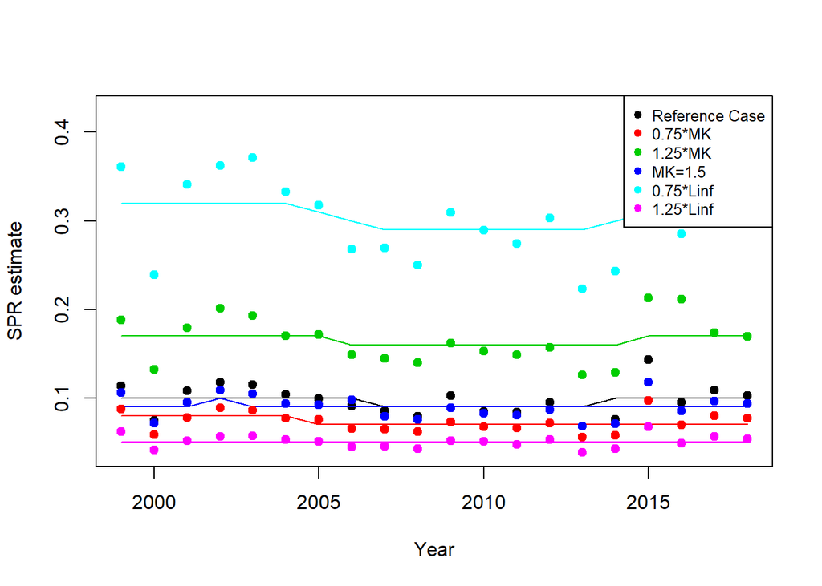

```r
smoothEsts1        <- data.frame(myFit@Ests)
smoothEsts1MK   <- data.frame(myFitMKLow@Ests)
smoothEsts2MK   <- data.frame(myFitMKSup@Ests)
smoothEsts3MK   <- data.frame(myFitMK15@Ests)
smoothEsts1Linf <- data.frame(myFitLinfLow@Ests)
smoothEsts2Linf <- data.frame(myFitLinfSup@Ests)


spr1     = myFit@SPR
sprmk1   = myFitMKLow@SPR
sprmk2   = myFitMKSup@SPR
sprmk3  = myFitMK15@SPR
sprL1 = myFitLinfLow@SPR
sprL2 = myFitLinfSup@SPR

fm1   = myFit@FM
fmmk1   = myFitMKLow@FM
fmmk2   = myFitMKSup@FM
fmmk3   = myFitMK15@FM
fmL1 = myFitLinfLow@FM
fmL2= myFitLinfSup@FM

min=min(c(spr1,sprmk1,sprmk2,sprmk3,sprL1,sprL2))
max=max(c(spr1,sprmk1,sprmk2,sprmk3,sprL1,sprL2))

plot(1999:2018,spr1,ylim=c(min,max),xlab="Year",ylab="SPR estimate",pch=19)

lines(1999:2018, smoothEsts1$SPR, lwd = 1,col="black")
lines(1999:2018, smoothEsts1MK$SPR, lwd = 1, col=2)
lines(1999:2018, smoothEsts2MK$SPR, lwd = 1, col=3)
lines(1999:2018, smoothEsts3MK$SPR, lwd = 1, col=4)
lines(1999:2018, smoothEsts1Linf$SPR, lwd = 1, col=5)
lines(1999:2018, smoothEsts2Linf$SPR, lwd = 1 ,col=6)


points(1999:2018, sprmk1,col=2,pch=19)
points(1999:2018, sprmk2,col=3,pch=19)
points(1999:2018, sprmk3,col=4,pch=19)
points(1999:2018, sprL1,col=5,pch=19)
points(1999:2018, sprL2,col=6, pch=19)


legend("topright", legend=c("Reference Case", "0.75*MK","1.25*MK","MK=1.5","0.75*Linf","1.25*Linf"),
       col=c("black", 2:6), pch=19, cex=0.8)
```

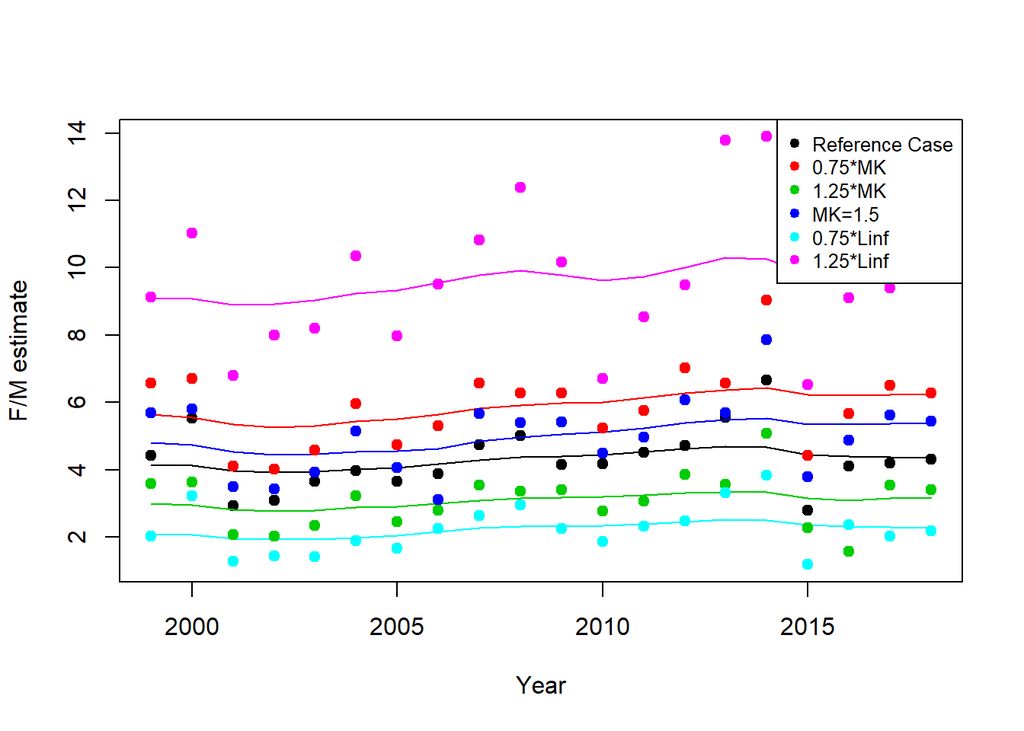

```r
min=min(c(fm1,fmmk1,fmmk2,fmmk3,fmL1,fmL2))
max=max(c(fm1,fmmk1,fmmk2,fmmk3,fmL1,fmL2))

plot(1999:2018,fm1,ylim=c(min,max),xlab="Year",ylab="F/M estimate",pch=19)

lines(1999:2018, smoothEsts1$FM, lwd = 1,col="black")
lines(1999:2018, smoothEsts1MK$FM, lwd = 1,col=2)
lines(1999:2018, smoothEsts2MK$FM, lwd = 1,col=3)
lines(1999:2018, smoothEsts3MK$FM, lwd = 1,col=4)
lines(1999:2018, smoothEsts1Linf$FM, lwd = 1, col=5)
lines(1999:2018, smoothEsts2Linf$FM, lwd = 1, col=6)


points(1999:2018, fmmk1,col=2,pch=19)
points(1999:2018, fmmk2,col=3,pch=19)
points(1999:2018, fmmk3,col=4,pch=19)
points(1999:2018, fmL1,col=5,pch=19)
points(1999:2018, fmL2,col=6,pch=19)

legend("topright", legend=c("Reference Case", "0.75*MK","1.25*MK","MK=1.5","0.75*Linf","1.25*Linf"),
       col=c("black", 2:6), pch=19, cex=0.8)
```